# NFLSuccess

#Load in nfl_pbp_1999_2020.rda

```r
load("C:/Users/colec/Desktop/ML/nfl_pbp_1999_2020.rda")
```

#Install and load required packages

```r
#install.packages(nflfastR)
#install.packages(tidyverse)
#install.packages(ggplot2)
#install.packages(ggdark)
#install.packages(ggimage)
#install.packages(GGally)
#install.packages(ggrepel)
#install.packages(scales)
#install.packages(dplyr)
#install.packages(plotly)
#install.packages(DT)
#install.packages(dplyr)
#install.packages(SparseDC)
#install.packages(xgboost)
#install.packages(caret)
#install.packages(reshape2)
library(nflfastR)
library(tidyverse)
library(ggplot2)
library(ggdark)
library(ggimage)
library(GGally)
library(ggrepel)
library(scales)
library(dplyr)
library(plotly)
library(DT)
library(dplyr)
library(SparseDC)
library(xgboost)
library(caret)
library(reshape2)
```

#Clean Data #Take out ‘no plays’ (penalties, etc) and special teams. Make plays where ball was not actually thrown but was designed as a pass as ‘pass’ and same thing for run. Run is easier but some plays were not listed as rush for various reason. For clustering, EPA > 0 would be a success.

```r
pbp <- pbp %>%
  filter(!is.na(epa), play_type=="no_play" | play_type=="pass" | play_type=="run") %>%
  mutate(pass = if_else(str_detect(desc, "(pass)|(sacked)|(scramble)"), 1, 0),
         rush = if_else(str_detect(desc, "(left end)|(left tackle)|(left guard)|(up the middle)|(right guard)|(right tackle)|(right end)") & pass == 0, 1, 0),
         success = ifelse(epa > 0 , 1, 0))

pbp <- pbp %>%
  filter(pass == 1 | rush == 1)

pbp
```

```
## # A tibble: 726,476 x 370
##    play_id game_id     old_game_id home_team away_team season_type  week posteam
##      <dbl> <chr>       <chr>       <chr>     <chr>     <chr>       <int> <chr>
##  1      60 1999_01_AR~ 1999091200  PHI       ARI       REG             1 PHI
##  2      82 1999_01_AR~ 1999091200  PHI       ARI       REG             1 PHI
##  3     126 1999_01_AR~ 1999091200  PHI       ARI       REG             1 PHI
##  4     176 1999_01_AR~ 1999091200  PHI       ARI       REG             1 ARI
##  5     197 1999_01_AR~ 1999091200  PHI       ARI       REG             1 ARI
##  6     218 1999_01_AR~ 1999091200  PHI       ARI       REG             1 ARI
##  7     260 1999_01_AR~ 1999091200  PHI       ARI       REG             1 PHI
##  8     281 1999_01_AR~ 1999091200  PHI       ARI       REG             1 PHI
##  9     305 1999_01_AR~ 1999091200  PHI       ARI       REG             1 PHI
## 10     326 1999_01_AR~ 1999091200  PHI       ARI       REG             1 PHI
## # ... with 726,466 more rows, and 362 more variables: posteam_type <chr>,
## #   defteam <chr>, side_of_field <chr>, yardline_100 <dbl>, game_date <chr>,
## #   quarter_seconds_remaining <dbl>, half_seconds_remaining <dbl>,
## #   game_seconds_remaining <dbl>, game_half <chr>, quarter_end <dbl>,
## #   drive <dbl>, sp <dbl>, qtr <dbl>, down <dbl>, goal_to_go <dbl>, time <chr>,
## #   yrdln <chr>, ydstogo <dbl>, ydsnet <dbl>, desc <chr>, play_type <chr>,
## #   yards_gained <dbl>, shotgun <dbl>, no_huddle <dbl>, qb_dropback <dbl>, ...
```

#Specify run gap as just OS or IS (outside or inside). Run plays up the middle originally had an NA value for gap.

```r
pbp$run_gap[(pbp$rush == 1) & (is.na(pbp$run_gap))] = 'center'

pbp <- pbp %>%
  mutate(OSrun = ifelse(run_gap == "end" | run_gap == 'tackle', 1, 0),
         ISrun = ifelse(run_gap == "guard" | run_gap == 'center', 1, 0),
         yps = air_yards - ydstogo)
```

#Add in weather values. Wind is by MPH while temperature is based on the degree. Explosive play is self-defined as a play that gains over 25 yards. This is a metric used by most every defense in America. A Third down converted variable is to be used as a variable to cluster teams into certain styles (offensive and defensive).

```r
pbp$highwind <- ifelse(pbp$wind >= 15, 1, 0)

pbp$cold <- ifelse((pbp$temp <= 25), 1, 0)

pbp$hot <- ifelse((pbp$temp >= 90), 1, 0)

pbp$rain <- ifelse((str_detect(pbp$weather, '(rain)')), 1, 0)

pbp$snow <- ifelse((str_detect(pbp$weather, '(snow)')), 1, 0)

pbp$explosive <- ifelse((pbp$yards_gained >= 25), 1, 0)

pbp$third_down_converted <- ifelse((pbp$down == 3), ifelse((pbp$yards_gained > pbp$ydstogo), 1, 0), NA)
```

#Further cleaning involves the Field Goal and Series Success situation. Before doing this work, field goals were always considered as an unsuccessful series.

```r
fgfix <- pbp %>%
  filter(series_result == 'Field goal' & play_type != 'no_play') %>%
  mutate(newseries = paste0(game_id, sep = "_", series))
```

#This loop adds a new column that marks the beginning yard line of each series.

```r
series <- unique(fgfix$newseries)
start <- rep(NA, length(series))
new_yrd <- stringr::str_split(fgfix$yrdln, " ")
series_start <- rep(NA,nrow(fgfix))
for(i in 1:length(series)){
  print(i)
  if(!is.null(new_yrd[[which(fgfix$newseries == series[i] &
                               fgfix$down == 1)[1]]])){
    start[i] <- new_yrd[[which(fgfix$newseries == series[i] &
                               fgfix$down == 1)[1]]][2]
  series_start[which(fgfix$newseries == series[i])] <- start[i]
       }

}
```

[output not shown]

[output cut: 16886 more lines]

```r
fgfix$series_start <- series_start
```

#This makes the field goal a successful result if the starting yard line for any given series is before the 25. Therefore, if further in the team shouldve scored a touchdown and not a field goal. Obviously this depends on in game situations and situational importance but this is a good general basis.

```r
fgfix$series_start <- as.numeric(fgfix$series_start)
fgfix$series_success <- ifelse((fgfix$series_start >= 25), 1, 0)

fgfix %>%
  select(newseries, down, yrdln, series_start, series_result, series_success)
```

```
## # A tibble: 49,226 x 6
##    newseries           down yrdln  series_start series_result series_success
##    <chr>              <dbl> <chr>         <dbl> <chr>                  <dbl>
##  1 1999_01_ARI_PHI_22     1 PHI 18           18 Field goal                 0
##  2 1999_01_ARI_PHI_22     2 PHI 14           18 Field goal                 0
##  3 1999_01_ARI_PHI_22     3 PHI 13           18 Field goal                 0
##  4 1999_01_ARI_PHI_24     1 PHI 11           11 Field goal                 0
##  5 1999_01_ARI_PHI_24     2 PHI 10           11 Field goal                 0
##  6 1999_01_ARI_PHI_24     3 PHI 10           11 Field goal                 0
##  7 1999_01_ARI_PHI_32     1 ARI 8             8 Field goal                 0
##  8 1999_01_ARI_PHI_32     2 ARI 16            8 Field goal                 0
##  9 1999_01_ARI_PHI_32     3 ARI 8             8 Field goal                 0
## 10 1999_01_ARI_PHI_46     1 PHI 21           21 Field goal                 0
## # ... with 49,216 more rows
```

###Clustering and Play Prediction

#This for loop creates new values for each team that will be used for offensive clustering. Pass Rate over expeceted, OS run rate, IS run rate, yards per pass attempt, yards after catch, Rate of QB scramble, hit, and sack, rate of pass on first down, air yards past the first down marker, interception and fumble average, average penalty yards, and third down conversion average. They will be binded into a df called datayrs that will give each teams values for each year.

```r
yrs <- c(1999:2020)
datayrs <- data.frame()
for (i in yrs) {
  perteamavgs <- pbp %>%
    filter(season == i) %>%
    group_by(posteam) %>%
    summarize(proe_avg = mean(pass_oe, na.rm = TRUE),
            outside_run_rate = mean(OSrun, na.rm = TRUE),
            inside_run_rate = mean(ISrun, na.rm = TRUE),
            yards_per_attempt = mean(air_yards, na.rm = TRUE),
            yac_avg = mean(yards_after_catch, na.rm = TRUE),
            qb_scramble_rate = mean(qb_scramble, na.rm = TRUE),
            qb_hit_rate = mean(qb_hit, na.rm = TRUE),
            qb_sack_rate = mean(sack, na.rm = TRUE),
            first_down_pass_rate = mean(first_down_pass, na.rm = TRUE),
            yards_over_sticks = mean(yps, na.rm = TRUE),
            int_avg = mean(interception, na.rm = TRUE),
            fumb_avg = mean(fumble_lost, na.rm = TRUE),
            penyd_avg = mean(penalty_yards, na.rm = TRUE),
            thrddnconv_avg = mean(third_down_converted, na.rm = TRUE))
  no_team_name <- perteamavgs %>%
  select(-posteam) %>%
  scale()

  datax <- data.frame(t(no_team_name))
  datayrs <- dplyr::bind_rows(datayrs, datax)

}
```

#Split data into seperate dfs for each year.

```r
data1999 <- datayrs[1:14,]
data2000 <- datayrs[15:28,]
data2001 <- datayrs[29:42,]
data2002 <- datayrs[43:56,]
data2003 <- datayrs[57:70,]
data2004 <- datayrs[71:84,]
data2005 <- datayrs[85:98,]
data2006 <- datayrs[99:112,]
data2007 <- datayrs[113:126,]
data2008 <- datayrs[127:140,]
data2009 <- datayrs[141:154,]
data2010 <- datayrs[155:168,]
data2011 <- datayrs[169:182,]
data2012 <- datayrs[183:196,]
data2013 <- datayrs[197:210,]
data2014 <- datayrs[211:224,]
data2015 <- datayrs[225:238,]
data2016 <- datayrs[239:252,]
data2017 <- datayrs[253:266,]
data2018 <- datayrs[267:280,]
data2019 <- datayrs[281:294,]
data2020 <- datayrs[295:308,]
```

#Example of what data will look like, y axis is each team.

```r
t(data2009)
```

```
##     proe_avg...141 outside_run_rate...142 inside_run_rate...143
## X1      1.47429931            1.219911273          -1.219911273
## X2     -0.15804039           -0.319443667           0.319443667
## X3     -0.14886144           -0.527869534           0.527869534
## X4     -0.50158961           -1.089950589           1.089950589
## X5     -1.74323721           -0.158488915           0.158488915
## X6      0.79040370           -0.304048390           0.304048390
## X7     -0.87929026            1.030672702          -1.030672702
## X8     -1.89270359           -1.072676982           1.072676982
## X9      0.27984894           -0.399008571           0.399008571
## X10     0.30432748           -0.131046539           0.131046539
## X11    -0.16213667            1.814603195          -1.814603195
## X12     0.95252912            1.145300547          -1.145300547
## X13     0.98709993            0.513059000          -0.513059000
## X14     1.35247094            1.482597144          -1.482597144
## X15     0.06117630           -2.465692222           2.465692222
## X16    -0.31110574            0.022594319          -0.022594319
## X17    -0.66691562           -0.071433169           0.071433169
## X18     0.44257180           -0.824893473           0.824893473
## X19    -0.69829053            0.683891612          -0.683891612
## X20    -1.09499621           -1.034657113           1.034657113
## X21     0.18702430           -0.004402556           0.004402556
## X22     0.94793747           -1.005961879           1.005961879
## X23     0.06237456           -0.125568825           0.125568825
## X24    -0.11265941            0.965505848          -0.965505848
## X25    -2.48352576           -0.091247056           0.091247056
## X26     1.45462780            0.686654751          -0.686654751
## X27     0.95874130           -0.482519422           0.482519422
## X28     0.66315728            0.812754001          -0.812754001
## X29     0.86989086           -1.949619447           1.949619447
## X30     0.10049060           -0.565898405           0.565898405
## X31    -1.58475178            0.913845098          -0.913845098
## X32     0.54913252            1.333037266          -1.333037266
##     yards_per_attempt...144 yac_avg...145 qb_scramble_rate...146
## X1              -0.62811836   -1.11522727            -0.99348389
## X2               0.18435978   -0.99756792            -0.57179974
## X3               0.49455713   -0.02158314             0.02996603
## X4              -0.25556351    0.15155123             1.36493238
## X5               1.00519924   -0.75353371            -0.72522763
## X6              -0.03046456   -0.79608589             0.21012560
```

[output cut: 110 more lines]

```
## X18            0.8784930
## X19           -1.5290127
## X20            1.6855815
## X21            0.7953192
## X22            1.2105087
## X23            1.0780784
## X24            0.8600357
## X25           -0.2486890
## X26           -0.7952344
## X27            0.1578546
## X28           -0.6508270
## X29           -1.7436513
## X30           -1.1054847
## X31            0.4613044
## X32            0.3677090
```

#Row Names are renamed because when the repeated values for the big datayrs df were inputed, extra ‘…2’ was added at the end. This was the simplest way for me to fix that issue.

```r
row.names(data1999) <- c("proe_avg", "outside_run_rate", "inside_run_rate", "yards_per_attempt", "yac_avg", "qb_scramble_rate", "qb_hit_rate", "qb_sack_rate", "first_down_pass_rate", "yards_over_sticks", "int_avg", "fumb_avg", "penyd_avg", "thrddnconv_avg")
row.names(data2000) <- c("proe_avg", "outside_run_rate", "inside_run_rate", "yards_per_attempt", "yac_avg", "qb_scramble_rate", "qb_hit_rate", "qb_sack_rate", "first_down_pass_rate", "yards_over_sticks", "int_avg", "fumb_avg", "penyd_avg", "thrddnconv_avg")
row.names(data2001) <- c("proe_avg", "outside_run_rate", "inside_run_rate", "yards_per_attempt", "yac_avg", "qb_scramble_rate", "qb_hit_rate", "qb_sack_rate", "first_down_pass_rate", "yards_over_sticks", "int_avg", "fumb_avg", "penyd_avg", "thrddnconv_avg")
row.names(data2002) <- c("proe_avg", "outside_run_rate", "inside_run_rate", "yards_per_attempt", "yac_avg", "qb_scramble_rate", "qb_hit_rate", "qb_sack_rate", "first_down_pass_rate", "yards_over_sticks", "int_avg", "fumb_avg", "penyd_avg", "thrddnconv_avg")
row.names(data2003) <- c("proe_avg", "outside_run_rate", "inside_run_rate", "yards_per_attempt", "yac_avg", "qb_scramble_rate", "qb_hit_rate", "qb_sack_rate", "first_down_pass_rate", "yards_over_sticks", "int_avg", "fumb_avg", "penyd_avg", "thrddnconv_avg")
row.names(data2004) <- c("proe_avg", "outside_run_rate", "inside_run_rate", "yards_per_attempt", "yac_avg", "qb_scramble_rate", "qb_hit_rate", "qb_sack_rate", "first_down_pass_rate", "yards_over_sticks", "int_avg", "fumb_avg", "penyd_avg", "thrddnconv_avg")
row.names(data2005) <- c("proe_avg", "outside_run_rate", "inside_run_rate", "yards_per_attempt", "yac_avg", "qb_scramble_rate", "qb_hit_rate", "qb_sack_rate", "first_down_pass_rate", "yards_over_sticks", "int_avg", "fumb_avg", "penyd_avg", "thrddnconv_avg")
row.names(data2006) <- c("proe_avg", "outside_run_rate", "inside_run_rate", "yards_per_attempt", "yac_avg", "qb_scramble_rate", "qb_hit_rate", "qb_sack_rate", "first_down_pass_rate", "yards_over_sticks", "int_avg", "fumb_avg", "penyd_avg", "thrddnconv_avg")
row.names(data2007) <- c("proe_avg", "outside_run_rate", "inside_run_rate", "yards_per_attempt", "yac_avg", "qb_scramble_rate", "qb_hit_rate", "qb_sack_rate", "first_down_pass_rate", "yards_over_sticks", "int_avg", "fumb_avg", "penyd_avg", "thrddnconv_avg")
row.names(data2008) <- c("proe_avg", "outside_run_rate", "inside_run_rate", "yards_per_attempt", "yac_avg", "qb_scramble_rate", "qb_hit_rate", "qb_sack_rate", "first_down_pass_rate", "yards_over_sticks", "int_avg", "fumb_avg", "penyd_avg", "thrddnconv_avg")
row.names(data2009) <- c("proe_avg", "outside_run_rate", "inside_run_rate", "yards_per_attempt", "yac_avg", "qb_scramble_rate", "qb_hit_rate", "qb_sack_rate", "first_down_pass_rate", "yards_over_sticks", "int_avg", "fumb_avg", "penyd_avg", "thrddnconv_avg")
row.names(data2010) <- c("proe_avg", "outside_run_rate", "inside_run_rate", "yards_per_attempt", "yac_avg", "qb_scramble_rate", "qb_hit_rate", "qb_sack_rate", "first_down_pass_rate", "yards_over_sticks", "int_avg", "fumb_avg", "penyd_avg", "thrddnconv_avg")
row.names(data2011) <- c("proe_avg", "outside_run_rate", "inside_run_rate", "yards_per_attempt", "yac_avg", "qb_scramble_rate", "qb_hit_rate", "qb_sack_rate", "first_down_pass_rate", "yards_over_sticks", "int_avg", "fumb_avg", "penyd_avg", "thrddnconv_avg")
row.names(data2012) <- c("proe_avg", "outside_run_rate", "inside_run_rate", "yards_per_attempt", "yac_avg", "qb_scramble_rate", "qb_hit_rate", "qb_sack_rate", "first_down_pass_rate", "yards_over_sticks", "int_avg", "fumb_avg", "penyd_avg", "thrddnconv_avg")
row.names(data2013) <- c("proe_avg", "outside_run_rate", "inside_run_rate", "yards_per_attempt", "yac_avg", "qb_scramble_rate", "qb_hit_rate", "qb_sack_rate", "first_down_pass_rate", "yards_over_sticks", "int_avg", "fumb_avg", "penyd_avg", "thrddnconv_avg")
row.names(data2014) <- c("proe_avg", "outside_run_rate", "inside_run_rate", "yards_per_attempt", "yac_avg", "qb_scramble_rate", "qb_hit_rate", "qb_sack_rate", "first_down_pass_rate", "yards_over_sticks", "int_avg", "fumb_avg", "penyd_avg", "thrddnconv_avg")
row.names(data2015) <- c("proe_avg", "outside_run_rate", "inside_run_rate", "yards_per_attempt", "yac_avg", "qb_scramble_rate", "qb_hit_rate", "qb_sack_rate", "first_down_pass_rate", "yards_over_sticks", "int_avg", "fumb_avg", "penyd_avg", "thrddnconv_avg")
row.names(data2016) <- c("proe_avg", "outside_run_rate", "inside_run_rate", "yards_per_attempt", "yac_avg", "qb_scramble_rate", "qb_hit_rate", "qb_sack_rate", "first_down_pass_rate", "yards_over_sticks", "int_avg", "fumb_avg", "penyd_avg", "thrddnconv_avg")
row.names(data2017) <- c("proe_avg", "outside_run_rate", "inside_run_rate", "yards_per_attempt", "yac_avg", "qb_scramble_rate", "qb_hit_rate", "qb_sack_rate", "first_down_pass_rate", "yards_over_sticks", "int_avg", "fumb_avg", "penyd_avg", "thrddnconv_avg")
row.names(data2018) <- c("proe_avg", "outside_run_rate", "inside_run_rate", "yards_per_attempt", "yac_avg", "qb_scramble_rate", "qb_hit_rate", "qb_sack_rate", "first_down_pass_rate", "yards_over_sticks", "int_avg", "fumb_avg", "penyd_avg", "thrddnconv_avg")
row.names(data2019) <- c("proe_avg", "outside_run_rate", "inside_run_rate", "yards_per_attempt", "yac_avg", "qb_scramble_rate", "qb_hit_rate", "qb_sack_rate", "first_down_pass_rate", "yards_over_sticks", "int_avg", "fumb_avg", "penyd_avg", "thrddnconv_avg")
row.names(data2020) <- c("proe_avg", "outside_run_rate", "inside_run_rate", "yards_per_attempt", "yac_avg", "qb_scramble_rate", "qb_hit_rate", "qb_sack_rate", "first_down_pass_rate", "yards_over_sticks", "int_avg", "fumb_avg", "penyd_avg", "thrddnconv_avg")
```

#The following clusters data for each year. The first clustering is between 1999 and 2000 and the next 2000 and 2001 and so on. I did this to link each year to try and create somewhat similar clusters year to year. SparceDC clustering helps link across years as well. After testing with 5 and 6 clusters, 4 was proved to be the ideal choice. lambda_1 controls how many of the cluster centers are non-zero. I divided this variable by three to lower it. Lowering it closer to zero makes more variables as factors for each cluster. lambda 2 controls the linking of clusters across conditions. I multiplied this by 1.25 as a higher value forces the clusters to have similar centers. At this point I also cut out the years 1999-2005 as they did not have all the data needed. This was acceptable because there would still be 15 years of data.

```r
lambda1 <- lambda1_calculator(pdat1 = data2006, pdat2 = data2007 ,
 ncluster=4, alpha1 = 0.5, nboot1 = 1000)
```

```r
lambda2 <- lambda2_calculator(pdat1 = data2006, pdat2 = data2007,
 ncluster = 4, alpha2 = 0.5, nboot2 = 1000)
```

```r
sdc_res <- sparsedc_cluster(pdat1 = data2006, pdat2 = data2007, ncluster = 4,
lambda1 = lambda1/3, lambda2 = lambda2*1.25, nitter = 20, nstarts =50)
```

```
## The number of unique start values is:  48
```

```r
clusters_2006 <- sdc_res$clusters1
clusters_2007 <- sdc_res$clusters1
centers_2006 <- sdc_res$centers2
centers_2007 <- sdc_res$centers2
rownames(centers_2006) <- colnames(no_team_name)
rownames(centers_2007) <- colnames(no_team_name)
```

```r
lambda1 <- lambda1_calculator(pdat1 = data2007, pdat2 = data2008,
 ncluster=4, alpha1 = 0.5, nboot1 = 1000)
```

```r
lambda2 <- lambda2_calculator(pdat1 = data2007, pdat2 = data2008,
 ncluster = 4, alpha2 = 0.5, nboot2 = 1000)
```

```r
sdc_res <- sparsedc_cluster(pdat1 = data2007, pdat2 = data2008, ncluster = 4,
lambda1 = lambda1/3, lambda2 = lambda2*1.25, nitter = 20, nstarts =50)
```

```
## The number of unique start values is:  49
```

```r
clusters_2008 <- sdc_res$clusters2
centers_2008 <- sdc_res$centers2
rownames(centers_2008) <- colnames(no_team_name)
```

```r
lambda1 <- lambda1_calculator(pdat1 = data2008, pdat2 = data2009,
 ncluster=4, alpha1 = 0.5, nboot1 = 1000)
```

```r
lambda2 <- lambda2_calculator(pdat1 = data2008, pdat2 = data2009,
 ncluster = 4, alpha2 = 0.5, nboot2 = 1000)
```

```r
sdc_res <- sparsedc_cluster(pdat1 = data2008, pdat2 = data2009, ncluster = 4,
lambda1 = lambda1/3, lambda2 = lambda2*1.25, nitter = 20, nstarts =50)
```

```
## The number of unique start values is:  48
```

```r
clusters_2009 <- sdc_res$clusters2
centers_2009 <- sdc_res$centers2
rownames(centers_2009) <- colnames(no_team_name)
```

```r
lambda1 <- lambda1_calculator(pdat1 = data2009, pdat2 = data2010,
 ncluster=4, alpha1 = 0.5, nboot1 = 1000)
```

```r
lambda2 <- lambda2_calculator(pdat1 = data2009, pdat2 = data2010,
 ncluster = 4, alpha2 = 0.5, nboot2 = 1000)
```

```r
sdc_res <- sparsedc_cluster(pdat1 = data2009, pdat2 = data2010, ncluster = 4,
lambda1 = lambda1/3, lambda2 = lambda2*1.25, nitter = 20, nstarts =50)
```

```
## The number of unique start values is:  50
```

```r
clusters_2010 <- sdc_res$clusters2
centers_2010 <- sdc_res$centers2
rownames(centers_2010) <- colnames(no_team_name)
```

```r
lambda1 <- lambda1_calculator(pdat1 = data2010, pdat2 = data2011,
 ncluster=4, alpha1 = 0.5, nboot1 = 1000)
```

```r
lambda2 <- lambda2_calculator(pdat1 = data2010, pdat2 = data2011,
 ncluster = 4, alpha2 = 0.5, nboot2 = 1000)
```

```r
sdc_res <- sparsedc_cluster(pdat1 = data2010, pdat2 = data2011, ncluster = 4,
lambda1 = lambda1/3, lambda2 = lambda2*1.25, nitter = 20, nstarts =50)
```

```
## The number of unique start values is:  45
```

```r
clusters_2011 <- sdc_res$clusters2
centers_2011 <- sdc_res$centers2
rownames(centers_2011) <- colnames(no_team_name)
```

```r
lambda1 <- lambda1_calculator(pdat1 = data2011, pdat2 = data2012,
 ncluster=4, alpha1 = 0.5, nboot1 = 1000)
```

```r
lambda2 <- lambda2_calculator(pdat1 = data2011, pdat2 = data2012,
 ncluster = 4, alpha2 = 0.5, nboot2 = 1000)
```

```r
sdc_res <- sparsedc_cluster(pdat1 = data2011, pdat2 = data2012, ncluster = 4,
lambda1 = lambda1/3, lambda2 = lambda2*1.25, nitter = 20, nstarts =50)
```

```
## The number of unique start values is:  45
```

```r
clusters_2012 <- sdc_res$clusters2
centers_2012 <- sdc_res$centers2
rownames(centers_2012) <- colnames(no_team_name)
```

```r
lambda1 <- lambda1_calculator(pdat1 = data2012, pdat2 = data2013,
 ncluster=4, alpha1 = 0.5, nboot1 = 1000)
```

```r
lambda2 <- lambda2_calculator(pdat1 = data2012, pdat2 = data2013,
 ncluster = 4, alpha2 = 0.5, nboot2 = 1000)
```

```r
sdc_res <- sparsedc_cluster(pdat1 = data2012, pdat2 = data2013, ncluster = 4,
lambda1 = lambda1/3, lambda2 = lambda2*1.25, nitter = 20, nstarts =50)
```

```
## The number of unique start values is:  39
```

```r
clusters_2013 <- sdc_res$clusters2
centers_2013 <- sdc_res$centers2
rownames(centers_2013) <- colnames(no_team_name)
```

```r
lambda1 <- lambda1_calculator(pdat1 = data2013, pdat2 = data2014,
 ncluster=4, alpha1 = 0.5, nboot1 = 1000)
```

```r
lambda2 <- lambda2_calculator(pdat1 = data2013, pdat2 = data2014,
 ncluster = 4, alpha2 = 0.5, nboot2 = 1000)
```

```r
sdc_res <- sparsedc_cluster(pdat1 = data2013, pdat2 = data2014, ncluster = 4,
lambda1 = lambda1/3, lambda2 = lambda2*1.25, nitter = 20, nstarts =50)
```

```
## The number of unique start values is:  48
```

```r
clusters_2014 <- sdc_res$clusters2
centers_2014 <- sdc_res$centers2
rownames(centers_2014) <- colnames(no_team_name)
```

```r
lambda1 <- lambda1_calculator(pdat1 = data2014, pdat2 = data2015,
 ncluster=4, alpha1 = 0.5, nboot1 = 1000)
```

```r
lambda2 <- lambda2_calculator(pdat1 = data2014, pdat2 = data2015,
 ncluster = 4, alpha2 = 0.5, nboot2 = 1000)
```

```r
sdc_res <- sparsedc_cluster(pdat1 = data2014, pdat2 = data2015, ncluster = 4,
lambda1 = lambda1/3, lambda2 = lambda2*1.25, nitter = 20, nstarts =50)
```

```
## The number of unique start values is:  47
```

```r
clusters_2015 <- sdc_res$clusters2
centers_2015 <- sdc_res$centers2
rownames(centers_2015) <- colnames(no_team_name)
```

```r
lambda1 <- lambda1_calculator(pdat1 = data2015, pdat2 = data2016,
 ncluster=4, alpha1 = 0.5, nboot1 = 1000)
```

```r
lambda2 <- lambda2_calculator(pdat1 = data2015, pdat2 = data2016,
 ncluster = 4, alpha2 = 0.5, nboot2 = 1000)
```

```r
sdc_res <- sparsedc_cluster(pdat1 = data2015, pdat2 = data2016, ncluster = 4,
lambda1 = lambda1/3, lambda2 = lambda2*1.25, nitter = 20, nstarts =50)
```

```
## The number of unique start values is:  49
```

```r
clusters_2016 <- sdc_res$clusters2
centers_2016 <- sdc_res$centers2
rownames(centers_2016) <- colnames(no_team_name)
```

```r
lambda1 <- lambda1_calculator(pdat1 = data2016, pdat2 = data2017,
 ncluster=4, alpha1 = 0.5, nboot1 = 1000)
```

```r
lambda2 <- lambda2_calculator(pdat1 = data2016, pdat2 = data2017,
 ncluster = 4, alpha2 = 0.5, nboot2 = 1000)
```

```r
sdc_res <- sparsedc_cluster(pdat1 = data2016, pdat2 = data2017, ncluster = 4,
lambda1 = lambda1/3, lambda2 = lambda2*1.25, nitter = 20, nstarts =50)
```

```
## The number of unique start values is:  46
```

```r
clusters_2017 <- sdc_res$clusters2
centers_2017 <- sdc_res$centers2
rownames(centers_2017) <- colnames(no_team_name)
```

```r
lambda1 <- lambda1_calculator(pdat1 = data2017, pdat2 = data2018,
 ncluster=4, alpha1 = 0.5, nboot1 = 1000)
```

```r
lambda2 <- lambda2_calculator(pdat1 = data2017, pdat2 = data2018,
 ncluster = 4, alpha2 = 0.5, nboot2 = 1000)
```

```r
sdc_res <- sparsedc_cluster(pdat1 = data2017, pdat2 = data2018, ncluster = 4,
lambda1 = lambda1/3, lambda2 = lambda2*1.25, nitter = 20, nstarts =50)
```

```
## The number of unique start values is:  48
```

```r
clusters_2018 <- sdc_res$clusters2
centers_2018 <- sdc_res$centers2
rownames(centers_2018) <- colnames(no_team_name)
```

```r
lambda1 <- lambda1_calculator(pdat1 = data2018, pdat2 = data2019,
 ncluster=4, alpha1 = 0.5, nboot1 = 1000)
```

```r
lambda2 <- lambda2_calculator(pdat1 = data2018, pdat2 = data2019,
 ncluster = 4, alpha2 = 0.5, nboot2 = 1000)
```

```r
sdc_res <- sparsedc_cluster(pdat1 = data2018, pdat2 = data2019, ncluster = 4,
lambda1 = lambda1/3, lambda2 = lambda2*1.25, nitter = 20, nstarts =50)
```

```
## The number of unique start values is:  47
```

```r
clusters_2019 <- sdc_res$clusters2
centers_2019 <- sdc_res$centers2
rownames(centers_2019) <- colnames(no_team_name)
```

```r
lambda1 <- lambda1_calculator(pdat1 = data2019, pdat2 = data2020,
 ncluster=4, alpha1 = 0.5, nboot1 = 1000)
```

```r
lambda2 <- lambda2_calculator(pdat1 = data2019, pdat2 = data2020,
 ncluster = 4, alpha2 = 0.5, nboot2 = 1000)
```

```r
sdc_res <- sparsedc_cluster(pdat1 = data2019, pdat2 = data2020, ncluster = 4,
lambda1 = lambda1/3, lambda2 = lambda2*1.25, nitter = 20, nstarts =50)
```

```
## The number of unique start values is:  49
```

```r
clusters_2020 <- sdc_res$clusters2
centers_2020 <- sdc_res$centers2
rownames(centers_2020) <- colnames(no_team_name)
```

```r
centers_2006
```

```
##                               [,1]        [,2]        [,3]       [,4]
## proe_avg              0.0000000000  0.16495821 -0.93471202  0.0000000
## outside_run_rate      0.0000000000  0.19836996  0.00000000 -0.5943183
## inside_run_rate       0.0000000000 -0.19836996  0.00000000  0.5943183
## yards_per_attempt     0.0000000000  0.00000000  0.91722993 -0.7396100
## yac_avg              -0.5241229452  0.06008345  0.00000000  0.1251126
## qb_scramble_rate     -0.0004557355 -0.29838359  1.02474141  0.1354514
## qb_hit_rate           1.0836509031 -0.40124946 -0.02110201  0.0000000
## qb_sack_rate          0.9689055713 -0.36554440  0.00000000  0.0000000
## first_down_pass_rate  0.0000000000  0.44452800 -0.68182938 -0.2982959
## yards_over_sticks     0.0000000000  0.00000000  0.84980121 -0.7420742
## int_avg               0.7557226464 -0.16270560  0.00000000  0.0000000
## fumb_avg              0.5978703105 -0.14022206  0.00000000  0.0000000
## penyd_avg             0.0000000000  0.01815713  0.00000000 -0.2672922
## thrddnconv_avg       -0.5791315460  0.38001373  0.00000000 -0.1010955
```

```r
centers_2007
```

```
##                               [,1]        [,2]        [,3]       [,4]
## proe_avg              0.0000000000  0.16495821 -0.93471202  0.0000000
## outside_run_rate      0.0000000000  0.19836996  0.00000000 -0.5943183
## inside_run_rate       0.0000000000 -0.19836996  0.00000000  0.5943183
## yards_per_attempt     0.0000000000  0.00000000  0.91722993 -0.7396100
## yac_avg              -0.5241229452  0.06008345  0.00000000  0.1251126
## qb_scramble_rate     -0.0004557355 -0.29838359  1.02474141  0.1354514
## qb_hit_rate           1.0836509031 -0.40124946 -0.02110201  0.0000000
## qb_sack_rate          0.9689055713 -0.36554440  0.00000000  0.0000000
## first_down_pass_rate  0.0000000000  0.44452800 -0.68182938 -0.2982959
## yards_over_sticks     0.0000000000  0.00000000  0.84980121 -0.7420742
## int_avg               0.7557226464 -0.16270560  0.00000000  0.0000000
## fumb_avg              0.5978703105 -0.14022206  0.00000000  0.0000000
## penyd_avg             0.0000000000  0.01815713  0.00000000 -0.2672922
## thrddnconv_avg       -0.5791315460  0.38001373  0.00000000 -0.1010955
```

```r
centers_2008
```

```
##                            [,1]         [,2]        [,3]         [,4]
## proe_avg              0.5711869  0.290832708 -0.80932393  0.000000000
## outside_run_rate      0.0000000  0.885836905  0.00000000 -0.414920291
## inside_run_rate       0.0000000 -0.885836905  0.00000000  0.414920291
## yards_per_attempt     0.0000000  0.000000000  0.57927066 -0.290504387
## yac_avg               0.0000000  0.194500107  0.00000000  0.000000000
## qb_scramble_rate     -0.2823087  0.000000000  0.00000000  0.315044095
## qb_hit_rate          -0.7932106  0.250261368 -0.37009676  0.580703702
## qb_sack_rate         -0.8123411  0.000000000  0.00000000  0.538693338
## first_down_pass_rate  0.9409970  0.127136707 -0.57114657 -0.230739726
## yards_over_sticks     0.0000000  0.000000000  0.62133461 -0.422196381
## int_avg               0.0000000  0.000000000 -0.16849350  0.002426453
## fumb_avg             -0.2305894  0.000000000 -0.04458731  0.180269375
## penyd_avg             0.0000000 -0.258206866  0.30356494  0.000000000
## thrddnconv_avg        0.7819229 -0.003054719  0.00000000 -0.276910594
```

```r
centers_2009
```

```
##                             [,1]       [,2]       [,3]       [,4]
## proe_avg             -0.99272618  0.0000000  0.3398671  0.3166955
## outside_run_rate      0.16424824 -0.6781825  0.3230038  0.0000000
## inside_run_rate      -0.16424824  0.6781825 -0.3230038  0.0000000
## yards_per_attempt     0.57044082 -0.3076775 -1.0223857  0.1404969
## yac_avg               0.00000000 -0.2258526  0.5431601  0.0000000
## qb_scramble_rate      0.00000000  0.8137128  0.0000000 -0.3399099
## qb_hit_rate          -0.10151373  0.5944894  0.2397563 -0.3599821
## qb_sack_rate          0.00000000  0.5091176  0.0000000 -0.2995692
## first_down_pass_rate -0.76004973 -0.2268242  0.4540750  0.5185645
## yards_over_sticks     0.51598644 -0.3783194 -1.0492160  0.2380192
## int_avg               0.00000000  0.1449011  0.0000000 -0.1085986
## fumb_avg              0.03679542  0.0000000  0.3268553 -0.2163500
## penyd_avg             0.00000000  0.0000000  0.0000000  0.0000000
## thrddnconv_avg       -0.26895218 -0.2085341  0.0000000  0.5230607
```

```r
centers_2010
```

```
##                             [,1]       [,2]       [,3]        [,4]
## proe_avg              0.39153546  0.0000000 -0.8980687  0.00000000
## outside_run_rate      0.16280733  0.1641510  0.0000000 -0.96251225
## inside_run_rate      -0.16280733 -0.1641510  0.0000000  0.96251225
## yards_per_attempt    -0.06568674  0.0000000  0.4710523  0.00000000
## yac_avg               0.22572118  0.0000000 -0.4299472  0.00000000
## qb_scramble_rate     -0.35152089  0.4496779 -0.0410909  0.08003117
## qb_hit_rate          -0.24359634  0.6127051 -0.7275145  0.31782199
## qb_sack_rate         -0.42088170  0.7093028 -0.3951451  0.18472081
## first_down_pass_rate  0.79423416 -0.4033866 -0.3178676 -0.05198459
## yards_over_sticks     0.00000000 -0.0546366  0.5568912  0.00000000
## int_avg              -0.31428120  0.6429660  0.0000000  0.00000000
## fumb_avg              0.00000000  0.0000000  0.0000000  0.00000000
## penyd_avg            -0.07072993  0.0000000  0.0000000  0.12197287
## thrddnconv_avg        0.56991828 -0.7373521  0.0000000  0.00000000
```

```r
centers_2011
```

```
##                             [,1]       [,2]        [,3]        [,4]
## proe_avg              0.08117172  0.0000000 -0.32729839  1.14834944
## outside_run_rate      0.09175834  0.4934624 -0.64084111  0.48552534
## inside_run_rate      -0.09175834 -0.4934624  0.64084111 -0.48552534
## yards_per_attempt    -0.30608214  0.0000000  0.07798496  0.42378682
## yac_avg               0.02219463  0.0000000 -0.19555743  0.50146821
## qb_scramble_rate     -0.49664514  0.0000000  0.00000000  1.86297027
## qb_hit_rate          -0.46699424  0.8202736  0.00000000  0.00000000
## qb_sack_rate         -0.66667030  0.8888008  0.00000000  0.00000000
## first_down_pass_rate  0.61518999 -0.4114331 -0.25324959  0.10082908
## yards_over_sticks    -0.20378403  0.0000000  0.08340115  0.36842015
## int_avg              -0.07929462  0.2530787  0.00000000  0.00000000
## fumb_avg             -0.09569839  0.1537169  0.00000000  0.00000000
## penyd_avg            -0.22772735  0.0000000  0.31988421 -0.61384161
## thrddnconv_avg        0.47431037 -0.7460715  0.00000000  0.03418188
```

```r
centers_2012
```

```
##                             [,1]        [,2]        [,3]         [,4]
## proe_avg              0.00000000  0.75897661  0.00000000 -0.373471003
## outside_run_rate     -0.72279028  0.00000000  0.00000000  0.717846904
## inside_run_rate       0.72279028  0.00000000  0.00000000 -0.717846904
## yards_per_attempt    -0.33791266 -0.07685295  1.24580872 -0.007522976
## yac_avg               0.00000000  0.09600993  0.00000000  0.000000000
## qb_scramble_rate      0.00000000 -0.31719488  0.29718072  0.000000000
## qb_hit_rate           0.00000000 -0.33760830  0.00000000  0.452703041
## qb_sack_rate          0.06695652 -0.43872930  0.00000000  0.201653533
## first_down_pass_rate -0.19912775  1.13588425 -0.05629235 -0.267588019
## yards_over_sticks    -0.29754903  0.00000000  1.11641062 -0.169878348
## int_avg               0.13271755 -0.20288125  0.00000000  0.000000000
## fumb_avg              0.26543728 -0.23707892  0.00000000  0.000000000
## penyd_avg             0.00000000 -0.22740899  0.00000000  0.000000000
## thrddnconv_avg        0.00000000  0.84456181  0.00000000 -0.481937116
```

```r
centers_2013
```

```
##                             [,1]        [,2]       [,3]        [,4]
## proe_avg              0.37901159  0.00000000 -0.2035232 -0.16032846
## outside_run_rate      0.00000000 -0.58081874  0.9789212 -0.05923398
## inside_run_rate       0.00000000  0.58081874 -0.9789212  0.05923398
## yards_per_attempt     0.00000000 -0.82999746  0.1734442  0.36770881
## yac_avg               0.00000000  0.32341741  0.5546093 -0.61454996
## qb_scramble_rate     -0.63295375  0.00000000  0.9843964  0.00000000
## qb_hit_rate          -0.62292288  0.00000000  0.0000000  0.21342832
## qb_sack_rate         -0.96743819  0.00000000  0.1252807  0.35958118
## first_down_pass_rate  0.93623924  0.00000000 -0.1151935 -0.42610808
## yards_over_sticks     0.00000000 -0.79018086  0.0000000  0.23682132
## int_avg              -0.04871713  0.00000000 -0.6613639  0.41813911
## fumb_avg              0.00000000  0.06243061  0.0000000  0.00000000
## penyd_avg             0.00000000  0.00000000  0.0000000  0.00000000
## thrddnconv_avg        0.64120024 -0.06930056  0.0000000 -0.30899233
```

```r
centers_2014
```

```
##                            [,1]        [,2]        [,3]        [,4]
## proe_avg              0.1491895  0.00000000 -0.39148509  0.33418152
## outside_run_rate     -0.2965627  1.31343103  0.00000000 -0.10280158
## inside_run_rate       0.2965627 -1.31343103  0.00000000  0.10280158
## yards_per_attempt    -0.8495302  0.00000000  0.64657992  0.00000000
## yac_avg               0.0000000  0.73774451 -0.49810444  0.00000000
## qb_scramble_rate      0.0000000  0.06944598  0.09726553 -0.46584039
## qb_hit_rate           0.1193801  0.00000000  0.14331900 -0.43565153
## qb_sack_rate          0.1292484  0.00000000  0.24461142 -0.76888233
## first_down_pass_rate -0.0683791  0.00000000 -0.45961871  0.81021828
## yards_over_sticks    -0.9102729  0.00000000  0.53405248  0.00000000
## int_avg               0.0000000 -0.18734445  0.18179956 -0.05352116
## fumb_avg              0.0000000  0.00000000  0.00000000  0.00000000
## penyd_avg            -0.2656681  0.00000000  0.00000000  0.00000000
## thrddnconv_avg       -0.3633721  0.07701145 -0.25506256  0.64252562
```

```r
centers_2015
```

```
##                             [,1]        [,2]          [,3]        [,4]
## proe_avg              0.16779254 -0.04756288  0.0007801819 -0.14714279
## outside_run_rate      0.74880723  0.00000000 -0.7255537574  0.00000000
## inside_run_rate      -0.74880723  0.00000000  0.7255537574  0.00000000
## yards_per_attempt    -0.22223582 -0.35868220  0.0000000000  0.95428409
## yac_avg               0.00000000  0.68577409  0.0000000000 -0.64451525
## qb_scramble_rate     -0.16077351  0.79784765 -0.4194749298  0.00000000
## qb_hit_rate           0.00000000  0.56899959 -0.5131723158  0.04600570
## qb_sack_rate         -0.07768768  0.75899787 -0.3958770624  0.00000000
## first_down_pass_rate  0.55120073 -0.79613997  0.0500692356  0.00000000
## yards_over_sticks    -0.16222135 -0.44886004  0.0000000000  0.86476105
## int_avg               0.00000000 -0.09364595  0.0000000000  0.00000000
## fumb_avg              0.17927636  0.00000000 -0.2115477683  0.00000000
## penyd_avg             0.00000000 -0.01922959  0.2702023950 -0.01105353
## thrddnconv_avg        0.37278354 -0.32774161  0.0000000000  0.00000000
```

```r
centers_2016
```

```
##                             [,1]        [,2]        [,3]        [,4]
## proe_avg              0.00000000 -0.29552826  0.07268366  0.00000000
## outside_run_rate      0.00000000  0.00000000 -0.59052868  1.14531035
## inside_run_rate       0.00000000  0.00000000  0.59052868 -1.14531035
## yards_per_attempt     0.00000000  1.06503006 -0.41798701 -0.22449542
## yac_avg               0.00000000 -0.73419341  0.23583938  0.11840381
## qb_scramble_rate      0.55992042  0.00000000 -0.42885950  0.00000000
## qb_hit_rate           0.62495672  0.00000000 -0.45182485  0.00000000
## qb_sack_rate          0.95222200 -0.04607797 -0.35022871 -0.03610479
## first_down_pass_rate -0.17154473  0.00000000  0.14405509  0.00000000
## yards_over_sticks     0.00000000  1.02916935 -0.37051705 -0.18214187
## int_avg               0.00000000  0.17994910 -0.07946769  0.00000000
## fumb_avg              0.08040519  0.00000000 -0.11504151  0.00000000
## penyd_avg             0.00000000  0.00000000  0.00000000  0.00000000
## thrddnconv_avg       -0.29006396  0.00000000  0.00000000  0.00000000
```

```r
centers_2017
```

```
##                             [,1]        [,2]        [,3]        [,4]
## proe_avg              0.00000000  0.69106053 -0.85667157  0.02415568
## outside_run_rate     -0.25393741  0.82845078  0.01015383 -0.45622257
## inside_run_rate       0.25393741 -0.82845078 -0.01015383  0.45622257
## yards_per_attempt     0.83601155  0.00000000  0.00000000 -0.43390292
## yac_avg              -0.18058448  0.04912388 -0.17352949  0.18291486
## qb_scramble_rate      0.00000000  0.15919896  0.39357976 -0.62763118
## qb_hit_rate           0.56891065  0.35764618  0.00000000 -0.67602764
## qb_sack_rate          0.37509799  0.00000000  0.12911133 -0.65056721
## first_down_pass_rate  0.00000000  0.39517439 -0.77631127  0.12632890
## yards_over_sticks     0.76636358  0.00000000  0.00000000 -0.33848399
## int_avg               0.78840043 -0.03789709  0.00000000 -0.17109173
## fumb_avg              0.70278399 -0.28301683  0.00000000  0.00000000
## penyd_avg             0.00000000  0.00000000  0.00000000  0.00000000
## thrddnconv_avg       -0.04383934  0.12938517  0.00000000  0.00000000
```

```r
centers_2018
```

```
##                              [,1]        [,2]        [,3]       [,4]
## proe_avg              0.766416396 -0.56277935  0.00000000  0.0000000
## outside_run_rate      0.819414659 -0.12951509  0.34770739 -0.5256839
## inside_run_rate      -0.819414659  0.12951509 -0.34770739  0.5256839
## yards_per_attempt     0.943358194  0.16353474 -0.57604945  0.0000000
## yac_avg               0.000000000 -0.09307365  0.31883718  0.0000000
## qb_scramble_rate      0.256394774  0.54548839 -0.20511206 -0.3754079
## qb_hit_rate           0.265189683  0.29922947  0.00000000 -0.7545613
## qb_sack_rate          0.000000000  0.59189001  0.10917915 -0.7827126
## first_down_pass_rate  0.729785990 -0.77134864  0.04626207  0.0000000
## yards_over_sticks     0.992830082  0.06560209 -0.64796670  0.0000000
## int_avg              -0.006579603  0.30302411 -0.06432911  0.0000000
## fumb_avg              0.000000000  0.00000000  0.17105984 -0.1322286
## penyd_avg             0.122421306  0.00000000 -0.36276812  0.1454923
## thrddnconv_avg        0.610466557 -0.04622315 -0.03669188  0.0000000
```

```r
centers_2019
```

```
##                              [,1]        [,2]       [,3]        [,4]
## proe_avg              0.000000000  0.30619867  0.0000000 -0.07491738
## outside_run_rate     -0.243291759  0.93055956  0.0000000 -0.23893277
## inside_run_rate       0.243291759 -0.93055956  0.0000000  0.23893277
## yards_per_attempt     0.890904129  0.00000000 -0.6178204 -0.16207139
## yac_avg              -0.288035718  0.00000000  0.0000000  0.00000000
## qb_scramble_rate      0.580386975 -0.05165717 -0.2359691  0.00000000
## qb_hit_rate           0.000000000  0.00000000 -0.4133775  0.58552523
## qb_sack_rate          0.033966866 -0.23745513 -0.2951358  0.80094339
## first_down_pass_rate -0.003167023  0.47875646  0.0000000 -0.26325668
## yards_over_sticks     0.887797323  0.00000000 -0.6028927 -0.24828987
## int_avg               0.251544226 -0.21672592  0.0000000  0.00000000
## fumb_avg              0.000000000  0.00000000 -0.3230310  0.88170777
## penyd_avg             0.001681427  0.00000000  0.1377460 -0.55201102
## thrddnconv_avg        0.000000000  0.41554369  0.0000000 -0.44841641
```

```r
centers_2020
```

```
##                             [,1]        [,2]        [,3]        [,4]
## proe_avg              0.00000000  0.00000000  0.00000000  0.00000000
## outside_run_rate     -0.95279067  0.00000000  0.67350885  0.01717017
## inside_run_rate       0.95279067  0.00000000 -0.67350885 -0.01717017
## yards_per_attempt     0.07855621 -1.05389301  0.00000000  0.27838205
## yac_avg               0.00000000  0.48872932  0.02739595 -0.44922124
## qb_scramble_rate      0.00000000 -0.38215666  0.00000000  0.14462429
## qb_hit_rate           0.00000000 -0.18514275 -0.38560305  0.72115954
## qb_sack_rate          0.00000000 -0.08221614 -0.69529253  0.63323372
## first_down_pass_rate -0.01717005  0.00000000  0.01072794  0.00000000
## yards_over_sticks     0.06481937 -1.04961824  0.07693669  0.21633103
## int_avg               0.28281666  0.00000000 -0.42636894  0.00000000
## fumb_avg              0.00000000 -0.37994768  0.00000000  0.12822035
## penyd_avg             0.38176417  0.00000000  0.00000000 -0.20568225
## thrddnconv_avg       -0.29523899  0.00000000  0.85832701 -0.08654184
```

#This is creating a bigger data frame with all the clusters in it. The y axis will be each team.

```r
f <- cbind.data.frame(perteamavgs$posteam, clusters_2006, clusters_2007, clusters_2008, clusters_2009, clusters_2010, clusters_2011, clusters_2012, clusters_2013, clusters_2014, clusters_2015, clusters_2016, clusters_2017, clusters_2018, clusters_2019, clusters_2020)

rownames(f) <- f$`perteamavgs$posteam`

f <- f[2:16]
fx <- as.data.frame(t(f))
fx$year <- rownames(fx)
fx$year <- substr(fx$year, 10,13)
fx <- melt(fx, id.vars=c("year"))
```

```r
fx$value[fx$year == 2006 & fx$value == 1] = 'Damage Control'
fx$value[fx$year == 2006 & fx$value == 2] = 'Balance'
fx$value[fx$year == 2006 & fx$value == 3] = 'Shots'
fx$value[fx$year == 2006 & fx$value == 4] = 'Ground & Pound'

fx$value[fx$year == 2007 & fx$value == 1] = 'Damage Control'
fx$value[fx$year == 2007 & fx$value == 2] = 'Balance'
fx$value[fx$year == 2007 & fx$value == 3] = 'Shots'
fx$value[fx$year == 2007 & fx$value == 4] = 'Ground & Pound'

fx$value[fx$year == 2008 & fx$value == 1] = 'Balance'
fx$value[fx$year == 2008 & fx$value == 2] = 'Ground & Pound'
fx$value[fx$year == 2008 & fx$value == 3] = 'Shots'
fx$value[fx$year == 2008 & fx$value == 4] = 'Damage Control'

fx$value[fx$year == 2009 & fx$value == 1] = 'Shots'
fx$value[fx$year == 2009 & fx$value == 2] = 'Damage Control'
fx$value[fx$year == 2009 & fx$value == 3] = 'Ground & Pound'
fx$value[fx$year == 2009 & fx$value == 4] = 'Balance'

fx$value[fx$year == 2010 & fx$value == 1] = 'Balance'
fx$value[fx$year == 2010 & fx$value == 2] = 'Damage Control'
fx$value[fx$year == 2010 & fx$value == 3] = 'Shots'
fx$value[fx$year == 2010 & fx$value == 4] = 'Ground & Pound'

fx$value[fx$year == 2011 & fx$value == 1] = 'Balance'
fx$value[fx$year == 2011 & fx$value == 2] = 'Damage Control'
fx$value[fx$year == 2011 & fx$value == 3] = 'Ground & Pound'
fx$value[fx$year == 2011 & fx$value == 4] = 'Shots'

fx$value[fx$year == 2012 & fx$value == 1] = 'Ground & Pound'
fx$value[fx$year == 2012 & fx$value == 2] = 'Balance'
fx$value[fx$year == 2012 & fx$value == 3] = 'Shots'
fx$value[fx$year == 2012 & fx$value == 4] = 'Damage Control'

fx$value[fx$year == 2013 & fx$value == 1] = 'Balance'
fx$value[fx$year == 2013 & fx$value == 2] = 'Ground & Pound'
fx$value[fx$year == 2013 & fx$value == 3] = 'Damage Control'
fx$value[fx$year == 2013 & fx$value == 4] = 'Shots'

fx$value[fx$year == 2014 & fx$value == 1] = 'Damage Control'
fx$value[fx$year == 2014 & fx$value == 2] = 'Ground & Pound'
fx$value[fx$year == 2014 & fx$value == 3] = 'Shots'
fx$value[fx$year == 2014 & fx$value == 4] = 'Balance'

fx$value[fx$year == 2015 & fx$value == 1] = 'Balance'
fx$value[fx$year == 2015 & fx$value == 2] = 'Damage Control'
fx$value[fx$year == 2015 & fx$value == 3] = 'Ground & Pound'
fx$value[fx$year == 2015 & fx$value == 4] = 'Shots'

fx$value[fx$year == 2016 & fx$value == 1] = 'Damage Control'
fx$value[fx$year == 2016 & fx$value == 2] = 'Shots'
fx$value[fx$year == 2016 & fx$value == 3] = 'Balance'
fx$value[fx$year == 2016 & fx$value == 4] = 'Ground & Pound'

fx$value[fx$year == 2017 & fx$value == 1] = 'Damage Control'
fx$value[fx$year == 2017 & fx$value == 2] = 'Shots'
fx$value[fx$year == 2017 & fx$value == 3] = 'Balance'
fx$value[fx$year == 2017 & fx$value == 4] = 'Ground & Pound'

fx$value[fx$year == 2018 & fx$value == 1] = 'Shots'
fx$value[fx$year == 2018 & fx$value == 2] = 'Damage Control'
fx$value[fx$year == 2018 & fx$value == 3] = 'Balance'
fx$value[fx$year == 2018 & fx$value == 4] = 'Ground & Pound'

fx$value[fx$year == 2019 & fx$value == 1] = 'Shots'
fx$value[fx$year == 2019 & fx$value == 2] = 'Balance'
fx$value[fx$year == 2019 & fx$value == 3] = 'Ground & Pound'
fx$value[fx$year == 2019 & fx$value == 4] = 'Damage Control'

fx$value[fx$year == 2020 & fx$value == 1] = 'Ground & Pound'
fx$value[fx$year == 2020 & fx$value == 2] = 'Balance'
fx$value[fx$year == 2020 & fx$value == 3] = 'Shots'
fx$value[fx$year == 2020 & fx$value == 4] = 'Damage Control'
```

#Here, visualizations of the clusters per team over the years are provided. For better clarity they are split up by Division.

```r
fxnw <- fx[fx$variable == 'ARI' | fx$variable == 'LA' | fx$variable == 'SEA' | fx$variable == 'SF', ]
fxnn <- fx[fx$variable == 'GB' | fx$variable == 'CHI' | fx$variable == 'MIN' | fx$variable == 'DET', ]
fxns <- fx[fx$variable == 'NO' | fx$variable == 'TB' | fx$variable == 'CAR' | fx$variable == 'ATL', ]
fxne <- fx[fx$variable == 'NYG' | fx$variable == 'WAS' | fx$variable == 'DAL' | fx$variable == 'PHI', ]
fxaw <- fx[fx$variable == 'DEN' | fx$variable == 'LAC' | fx$variable == 'LV' | fx$variable == 'KC', ]
fxan <- fx[fx$variable == 'CIN' | fx$variable == 'CLE' | fx$variable == 'PIT' | fx$variable == 'BAL', ]
fxas <- fx[fx$variable == 'IND' | fx$variable == 'TEN' | fx$variable == 'JAX' | fx$variable == 'HOU', ]
fxae <- fx[fx$variable == 'NE' | fx$variable == 'NYJ' | fx$variable == 'BUF' | fx$variable == 'MIA', ]
gfxnw <- ggplot(fxnw, aes(x=as.numeric(year), y=value, group=variable, color= variable)) +
  geom_line()
gfxnw <- gfxnw + scale_x_continuous(breaks = as.numeric(fxnw$year)) + ggtitle("NFC West") + xlab("Years") + ylab("Clusters")
gfxnn <- ggplot(fxnn, aes(x=as.numeric(year), y=value, group=variable, color=variable)) +
  geom_line()
gfxnn <- gfxnn + scale_x_continuous(breaks = as.numeric(fxnn$year)) + ggtitle("NFC North") + xlab("Years") + ylab("Clusters")
gfxns <- ggplot(fxns, aes(x=as.numeric(year), y=value, group=variable, color=variable)) +
  geom_line()
gfxns <- gfxns + scale_x_continuous(breaks = as.numeric(fxns$year)) + ggtitle("NFC South") + xlab("Years") + ylab("Clusters")
gfxne <- ggplot(fxne, aes(x=as.numeric(year), y=value, group=variable, color=variable)) +
  geom_line()
gfxne <- gfxne + scale_x_continuous(breaks = as.numeric(fxne$year)) + ggtitle("NFC East") + xlab("Years") + ylab("Clusters")
gfxaw <- ggplot(fxaw, aes(x=as.numeric(year), y=value, group=variable, color=variable)) +
  geom_line()
gfxaw <- gfxaw + scale_x_continuous(breaks = as.numeric(fxaw$year)) + ggtitle("AFC West") + xlab("Years") + ylab("Clusters")
gfxan <- ggplot(fxan, aes(x=as.numeric(year), y=value, group=variable, color=variable)) +
  geom_line()
gfxan <- gfxan + scale_x_continuous(breaks = as.numeric(fxan$year)) + ggtitle("AFC North") + xlab("Years") + ylab("Clusters")
gfxas <- ggplot(fxas, aes(x=as.numeric(year), y=value, group=variable, color=variable)) +
  geom_line()
gfxas <- gfxas + scale_x_continuous(breaks = as.numeric(fxas$year)) + ggtitle("AFC South") + xlab("Years") + ylab("Clusters")
gfxae <- ggplot(fxae, aes(x=as.numeric(year), y=value, group=variable, color=variable)) +
  geom_line()
gfxae <- gfxae + scale_x_continuous(breaks = as.numeric(fxae$year)) + ggtitle("AFC East") + xlab("Years") + ylab("Clusters")
```

#As shown, some teams move clusters over the years. This is acceptable as personnel (both coaches and players) changes over the years.

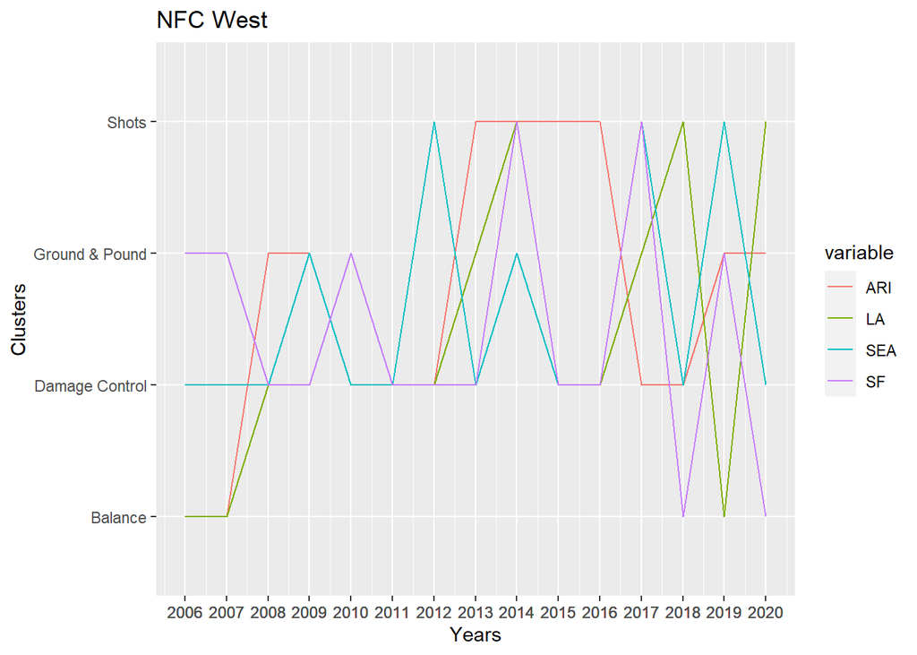

```r
gfxnw
```

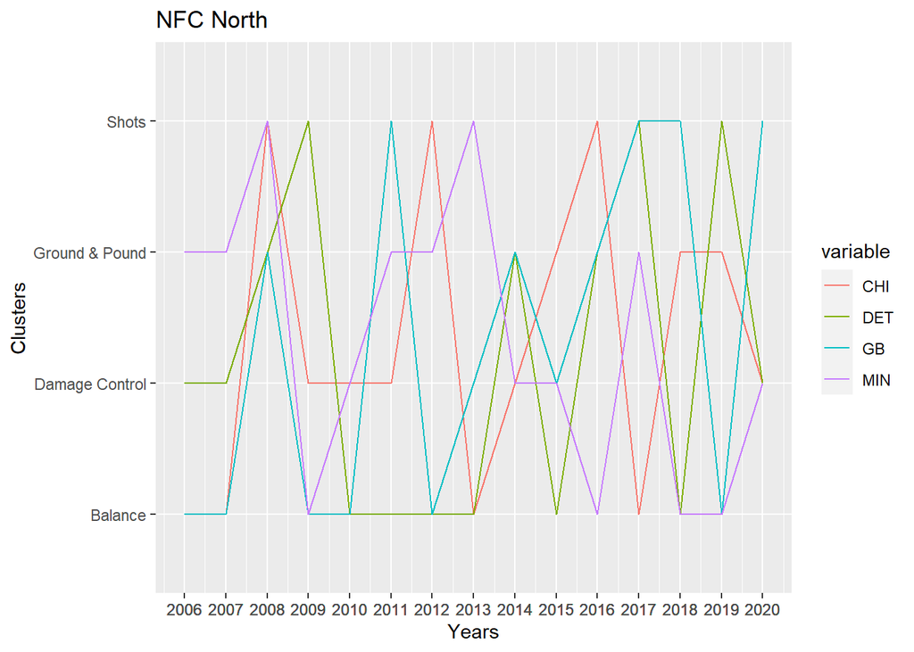

```r
gfxnn
```

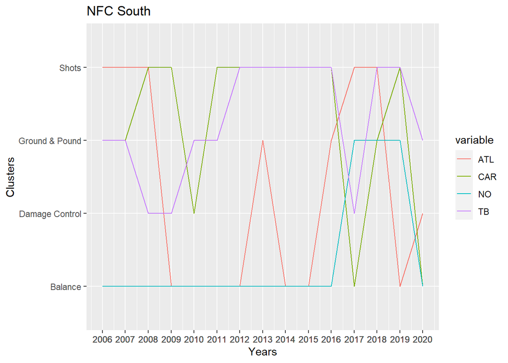

```r
gfxns
```

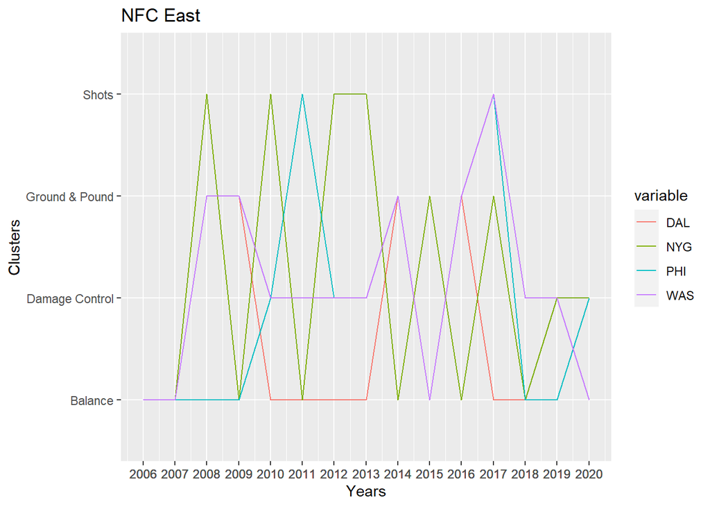

```r
gfxne
```

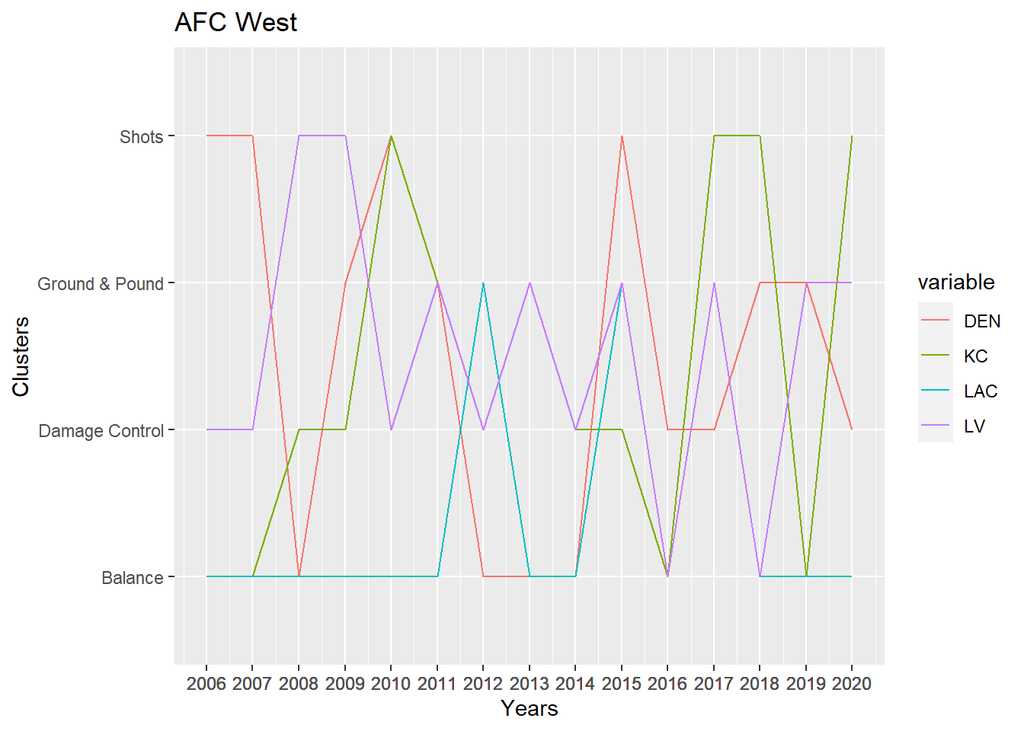

```r
gfxaw
```

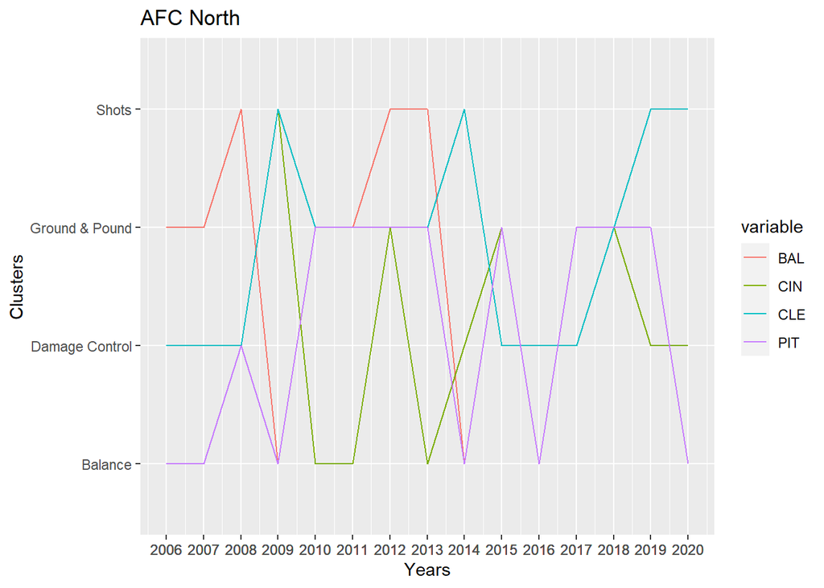

```r
gfxan
```

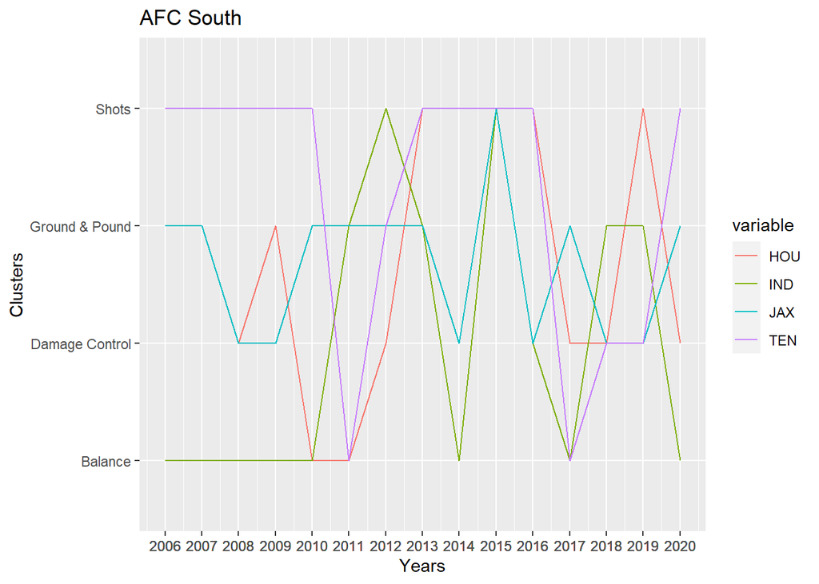

```r
gfxas
```

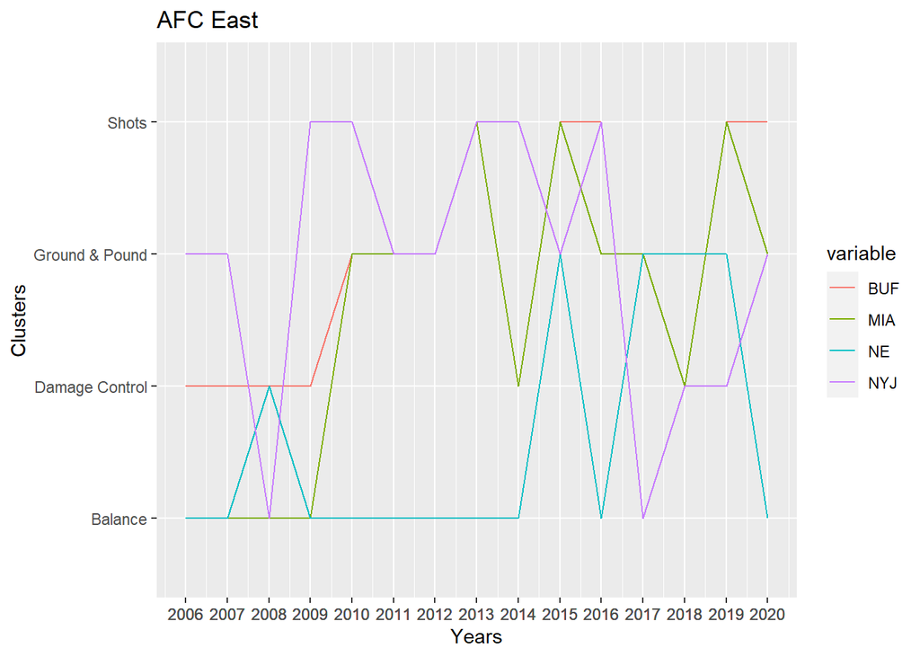

```r
gfxae
```

```r
yrsdef <- c(1999:2020)
datayrsdef <- data.frame()
for (i in yrsdef) {
  defavgs <- pbp %>%
    filter(season == i) %>%
    group_by(posteam) %>%
    summarize(qb_scramble_rate = mean(qb_scramble, na.rm = TRUE),
            qb_hit_rate = mean(qb_hit, na.rm = TRUE),
            qb_sack_rate = mean(sack, na.rm = TRUE),
            int_avg = mean(interception, na.rm = TRUE),
            fumb_avg = mean(fumble_lost, na.rm = TRUE),
            thrddnconv_avg = mean(third_down_converted, na.rm = TRUE),
            passyd_avg = mean(passing_yards, na.rm = TRUE),
            runyd_avg = mean(rushing_yards, na.rm = TRUE),
            exp_avg = mean(explosive, na.rm = TRUE))
  defno_team_name <- defavgs %>%
  select(-posteam) %>%
  scale()

  datadef <- data.frame(t(defno_team_name))
  datayrsdef <- dplyr::bind_rows(datayrsdef, datadef)
}
```

```r
defdata1999 <- datayrsdef[1:9,]
defdata2000 <- datayrsdef[10:18,]
defdata2001 <- datayrsdef[19:27,]
defdata2002 <- datayrsdef[28:36,]
defdata2003 <- datayrsdef[37:45,]
defdata2004 <- datayrsdef[46:54,]
defdata2005 <- datayrsdef[55:63,]
defdata2006 <- datayrsdef[64:72,]
defdata2007 <- datayrsdef[73:81,]
defdata2008 <- datayrsdef[82:90,]
defdata2009 <- datayrsdef[91:99,]
defdata2010 <- datayrsdef[100:108,]
defdata2011 <- datayrsdef[109:117,]
defdata2012 <- datayrsdef[118:126,]
defdata2013 <- datayrsdef[127:135,]
defdata2014 <- datayrsdef[136:144,]
defdata2015 <- datayrsdef[145:153,]
defdata2016 <- datayrsdef[154:162,]
defdata2017 <- datayrsdef[163:171,]
defdata2018 <- datayrsdef[172:180,]
defdata2019 <- datayrsdef[181:189,]
defdata2020 <- datayrsdef[190:198,]
```

```r
row.names(defdata1999) <- c("qb_scramble_rate", "qb_hit_rate", "qb_sack_rate", "int_avg", "fumb_avg", "thrddnconv_avg", "passyd_avg", "runyd_avg", "exp_avg")
row.names(defdata2000) <- c("qb_scramble_rate", "qb_hit_rate", "qb_sack_rate", "int_avg", "fumb_avg", "thrddnconv_avg", "passyd_avg", "runyd_avg", "exp_avg")
row.names(defdata2001) <- c("qb_scramble_rate", "qb_hit_rate", "qb_sack_rate", "int_avg", "fumb_avg", "thrddnconv_avg", "passyd_avg", "runyd_avg", "exp_avg")
row.names(defdata2002) <- c("qb_scramble_rate", "qb_hit_rate", "qb_sack_rate", "int_avg", "fumb_avg", "thrddnconv_avg", "passyd_avg", "runyd_avg", "exp_avg")
row.names(defdata2003) <- c("qb_scramble_rate", "qb_hit_rate", "qb_sack_rate", "int_avg", "fumb_avg", "thrddnconv_avg", "passyd_avg", "runyd_avg", "exp_avg")
row.names(defdata2004) <- c("qb_scramble_rate", "qb_hit_rate", "qb_sack_rate", "int_avg", "fumb_avg", "thrddnconv_avg", "passyd_avg", "runyd_avg", "exp_avg")
row.names(defdata2005) <- c("qb_scramble_rate", "qb_hit_rate", "qb_sack_rate", "int_avg", "fumb_avg", "thrddnconv_avg", "passyd_avg", "runyd_avg", "exp_avg")
row.names(defdata2006) <- c("qb_scramble_rate", "qb_hit_rate", "qb_sack_rate", "int_avg", "fumb_avg", "thrddnconv_avg", "passyd_avg", "runyd_avg", "exp_avg")
row.names(defdata2007) <- c("qb_scramble_rate", "qb_hit_rate", "qb_sack_rate", "int_avg", "fumb_avg", "thrddnconv_avg", "passyd_avg", "runyd_avg", "exp_avg")
row.names(defdata2008) <- c("qb_scramble_rate", "qb_hit_rate", "qb_sack_rate", "int_avg", "fumb_avg", "thrddnconv_avg", "passyd_avg", "runyd_avg", "exp_avg")
row.names(defdata2009) <- c("qb_scramble_rate", "qb_hit_rate", "qb_sack_rate", "int_avg", "fumb_avg", "thrddnconv_avg", "passyd_avg", "runyd_avg", "exp_avg")
row.names(defdata2010) <- c("qb_scramble_rate", "qb_hit_rate", "qb_sack_rate", "int_avg", "fumb_avg", "thrddnconv_avg", "passyd_avg", "runyd_avg", "exp_avg")
row.names(defdata2011) <- c("qb_scramble_rate", "qb_hit_rate", "qb_sack_rate", "int_avg", "fumb_avg", "thrddnconv_avg", "passyd_avg", "runyd_avg", "exp_avg")
row.names(defdata2012) <- c("qb_scramble_rate", "qb_hit_rate", "qb_sack_rate", "int_avg", "fumb_avg", "thrddnconv_avg", "passyd_avg", "runyd_avg", "exp_avg")
row.names(defdata2013) <- c("qb_scramble_rate", "qb_hit_rate", "qb_sack_rate", "int_avg", "fumb_avg", "thrddnconv_avg", "passyd_avg", "runyd_avg", "exp_avg")
row.names(defdata2014) <- c("qb_scramble_rate", "qb_hit_rate", "qb_sack_rate", "int_avg", "fumb_avg", "thrddnconv_avg", "passyd_avg", "runyd_avg", "exp_avg")
row.names(defdata2015) <- c("qb_scramble_rate", "qb_hit_rate", "qb_sack_rate", "int_avg", "fumb_avg", "thrddnconv_avg", "passyd_avg", "runyd_avg", "exp_avg")
row.names(defdata2016) <- c("qb_scramble_rate", "qb_hit_rate", "qb_sack_rate", "int_avg", "fumb_avg", "thrddnconv_avg", "passyd_avg", "runyd_avg", "exp_avg")
row.names(defdata2017) <- c("qb_scramble_rate", "qb_hit_rate", "qb_sack_rate", "int_avg", "fumb_avg", "thrddnconv_avg", "passyd_avg", "runyd_avg", "exp_avg")
row.names(defdata2018) <- c("qb_scramble_rate", "qb_hit_rate", "qb_sack_rate", "int_avg", "fumb_avg", "thrddnconv_avg", "passyd_avg", "runyd_avg", "exp_avg")
row.names(defdata2019) <- c("qb_scramble_rate", "qb_hit_rate", "qb_sack_rate", "int_avg", "fumb_avg", "thrddnconv_avg", "passyd_avg", "runyd_avg", "exp_avg")
row.names(defdata2020) <- c("qb_scramble_rate", "qb_hit_rate", "qb_sack_rate", "int_avg", "fumb_avg", "thrddnconv_avg", "passyd_avg", "runyd_avg", "exp_avg")
```

```r
lambda1 <- lambda1_calculator(pdat1 = defdata2006, pdat2 = defdata2007 ,
 ncluster=4, alpha1 = 0.5, nboot1 = 1000)
```

```r
lambda2 <- lambda2_calculator(pdat1 = defdata2006, pdat2 = defdata2007,
 ncluster = 4, alpha2 = 0.5, nboot2 = 1000)
```

```r
sdc_res <- sparsedc_cluster(pdat1 = defdata2006, pdat2 = defdata2007, ncluster = 4,
lambda1 = lambda1/3, lambda2 = lambda2*1.25, nitter = 20, nstarts =50)
```

```
## The number of unique start values is:  37
```

```r
defclusters_2006 <- sdc_res$clusters1
defclusters_2007 <- sdc_res$clusters1
defcenters_2006 <- sdc_res$centers2
defcenters_2007 <- sdc_res$centers2
rownames(defcenters_2006) <- colnames(defno_team_name)
rownames(defcenters_2007) <- colnames(defno_team_name)
```

```r
lambda1 <- lambda1_calculator(pdat1 = defdata2007, pdat2 = defdata2008,
 ncluster=4, alpha1 = 0.5, nboot1 = 1000)
```

```r
lambda2 <- lambda2_calculator(pdat1 = defdata2007, pdat2 = defdata2008,
 ncluster = 4, alpha2 = 0.5, nboot2 = 1000)
```

```r
sdc_res <- sparsedc_cluster(pdat1 = defdata2007, pdat2 = defdata2008, ncluster = 4,
lambda1 = lambda1/3, lambda2 = lambda2*1.25, nitter = 20, nstarts =50)
```

```
## The number of unique start values is:  44
```

```r
defclusters_2008 <- sdc_res$clusters2
defcenters_2008 <- sdc_res$centers2
rownames(defcenters_2008) <- colnames(defno_team_name)
```

```r
lambda1 <- lambda1_calculator(pdat1 = defdata2008, pdat2 = defdata2009,
 ncluster=4, alpha1 = 0.5, nboot1 = 1000)
```

```r
lambda2 <- lambda2_calculator(pdat1 = defdata2008, pdat2 = defdata2009,
 ncluster = 4, alpha2 = 0.5, nboot2 = 1000)
```

```r
sdc_res <- sparsedc_cluster(pdat1 = defdata2008, pdat2 = defdata2009, ncluster = 4,
lambda1 = lambda1/3, lambda2 = lambda2*1.25, nitter = 20, nstarts =50)
```

```
## The number of unique start values is:  50
```

```r
defclusters_2009 <- sdc_res$clusters2
defcenters_2009 <- sdc_res$centers2
rownames(defcenters_2009) <- colnames(defno_team_name)
```

```r
lambda1 <- lambda1_calculator(pdat1 = defdata2009, pdat2 = defdata2010,
 ncluster=4, alpha1 = 0.5, nboot1 = 1000)
```

```r
lambda2 <- lambda2_calculator(pdat1 = defdata2009, pdat2 = defdata2010,
 ncluster = 4, alpha2 = 0.5, nboot2 = 1000)
```

```r
sdc_res <- sparsedc_cluster(pdat1 = defdata2009, pdat2 = defdata2010, ncluster = 4,
lambda1 = lambda1/3, lambda2 = lambda2*1.25, nitter = 20, nstarts =50)
```

```
## The number of unique start values is:  44
```

```r
defclusters_2010 <- sdc_res$clusters2
defcenters_2010 <- sdc_res$centers2
rownames(defcenters_2010) <- colnames(defno_team_name)
```

```r
lambda1 <- lambda1_calculator(pdat1 = defdata2010, pdat2 = defdata2011,
 ncluster=4, alpha1 = 0.5, nboot1 = 1000)
```

```r
lambda2 <- lambda2_calculator(pdat1 = defdata2010, pdat2 = defdata2011,
 ncluster = 4, alpha2 = 0.5, nboot2 = 1000)
```

```r
sdc_res <- sparsedc_cluster(pdat1 = defdata2010, pdat2 = defdata2011, ncluster = 4,
lambda1 = lambda1/3, lambda2 = lambda2*1.25, nitter = 20, nstarts =50)
```

```
## The number of unique start values is:  44
```

```r
defclusters_2011 <- sdc_res$clusters2
defcenters_2011 <- sdc_res$centers2
rownames(defcenters_2011) <- colnames(defno_team_name)
```

```r
lambda1 <- lambda1_calculator(pdat1 = defdata2011, pdat2 = defdata2012,
 ncluster=4, alpha1 = 0.5, nboot1 = 1000)
```

```r
lambda2 <- lambda2_calculator(pdat1 = defdata2011, pdat2 = defdata2012,
 ncluster = 4, alpha2 = 0.5, nboot2 = 1000)
```

```r
sdc_res <- sparsedc_cluster(pdat1 = defdata2011, pdat2 = defdata2012, ncluster = 4,
lambda1 = lambda1/3, lambda2 = lambda2*1.25, nitter = 20, nstarts =50)
```

```
## The number of unique start values is:  50
```

```r
defclusters_2012 <- sdc_res$clusters2
defcenters_2012 <- sdc_res$centers2
rownames(defcenters_2012) <- colnames(defno_team_name)
```

```r
lambda1 <- lambda1_calculator(pdat1 = defdata2012, pdat2 = defdata2013,
 ncluster=4, alpha1 = 0.5, nboot1 = 1000)
```

```r
lambda2 <- lambda2_calculator(pdat1 = defdata2012, pdat2 = defdata2013,
 ncluster = 4, alpha2 = 0.5, nboot2 = 1000)
```

```r
sdc_res <- sparsedc_cluster(pdat1 = defdata2012, pdat2 = defdata2013, ncluster = 4,
lambda1 = lambda1/3, lambda2 = lambda2*1.25, nitter = 20, nstarts =50)
```

```
## The number of unique start values is:  44
```

```r
defclusters_2013 <- sdc_res$clusters2
defcenters_2013 <- sdc_res$centers2
rownames(defcenters_2013) <- colnames(defno_team_name)
```

```r
lambda1 <- lambda1_calculator(pdat1 = defdata2013, pdat2 = defdata2014,
 ncluster=4, alpha1 = 0.5, nboot1 = 1000)
```

```r
lambda2 <- lambda2_calculator(pdat1 = defdata2013, pdat2 = defdata2014,
 ncluster = 4, alpha2 = 0.5, nboot2 = 1000)
```

```r
sdc_res <- sparsedc_cluster(pdat1 = defdata2013, pdat2 = defdata2014, ncluster = 4,
lambda1 = lambda1/3, lambda2 = lambda2*1.25, nitter = 20, nstarts =50)
```

```
## The number of unique start values is:  49
```

```r
defclusters_2014 <- sdc_res$clusters2
defcenters_2014 <- sdc_res$centers2
rownames(defcenters_2014) <- colnames(defno_team_name)
```

```r
lambda1 <- lambda1_calculator(pdat1 = defdata2014, pdat2 = defdata2015,
 ncluster=4, alpha1 = 0.5, nboot1 = 1000)
```

```r
lambda2 <- lambda2_calculator(pdat1 = defdata2014, pdat2 = defdata2015,
 ncluster = 4, alpha2 = 0.5, nboot2 = 1000)
```

```r
sdc_res <- sparsedc_cluster(pdat1 = defdata2014, pdat2 = defdata2015, ncluster = 4,
lambda1 = lambda1/3, lambda2 = lambda2*1.25, nitter = 20, nstarts =50)
```

```
## The number of unique start values is:  41
```

```r
defclusters_2015 <- sdc_res$clusters2
defcenters_2015 <- sdc_res$centers2
rownames(defcenters_2015) <- colnames(defno_team_name)
```

```r
lambda1 <- lambda1_calculator(pdat1 = defdata2015, pdat2 = defdata2016,
 ncluster=4, alpha1 = 0.5, nboot1 = 1000)
```

```r
lambda2 <- lambda2_calculator(pdat1 = defdata2015, pdat2 = defdata2016,
 ncluster = 4, alpha2 = 0.5, nboot2 = 1000)
```

```r
sdc_res <- sparsedc_cluster(pdat1 = defdata2015, pdat2 = defdata2016, ncluster = 4,
lambda1 = lambda1/3, lambda2 = lambda2*1.25, nitter = 20, nstarts =50)
```

```
## The number of unique start values is:  50
```

```r
defclusters_2016 <- sdc_res$clusters2
defcenters_2016 <- sdc_res$centers2
rownames(defcenters_2016) <- colnames(defno_team_name)
```

```r
lambda1 <- lambda1_calculator(pdat1 = defdata2016, pdat2 = defdata2017,
 ncluster=4, alpha1 = 0.5, nboot1 = 1000)
```

```r
lambda2 <- lambda2_calculator(pdat1 = defdata2016, pdat2 = defdata2017,
 ncluster = 4, alpha2 = 0.5, nboot2 = 1000)
```

```r
sdc_res <- sparsedc_cluster(pdat1 = defdata2016, pdat2 = defdata2017, ncluster = 4,
lambda1 = lambda1/3, lambda2 = lambda2*1.25, nitter = 20, nstarts =50)
```

```
## The number of unique start values is:  31
```

```r
defclusters_2017 <- sdc_res$clusters2
defcenters_2017 <- sdc_res$centers2
rownames(defcenters_2017) <- colnames(defno_team_name)
```

```r
lambda1 <- lambda1_calculator(pdat1 = defdata2017, pdat2 = defdata2018,
 ncluster=4, alpha1 = 0.5, nboot1 = 1000)
```

```r
lambda2 <- lambda2_calculator(pdat1 = defdata2017, pdat2 = defdata2018,
 ncluster = 4, alpha2 = 0.5, nboot2 = 1000)
```

```r
sdc_res <- sparsedc_cluster(pdat1 = defdata2017, pdat2 = defdata2018, ncluster = 4,
lambda1 = lambda1/3, lambda2 = lambda2*1.25, nitter = 20, nstarts =50)
```

```
## The number of unique start values is:  50
```

```r
defclusters_2018 <- sdc_res$clusters2
defcenters_2018 <- sdc_res$centers2
rownames(defcenters_2018) <- colnames(defno_team_name)
```

```r
lambda1 <- lambda1_calculator(pdat1 = defdata2018, pdat2 = defdata2019,
 ncluster=4, alpha1 = 0.5, nboot1 = 1000)
```

```r
lambda2 <- lambda2_calculator(pdat1 = defdata2018, pdat2 = defdata2019,
 ncluster = 4, alpha2 = 0.5, nboot2 = 1000)
```

```r
sdc_res <- sparsedc_cluster(pdat1 = defdata2018, pdat2 = defdata2019, ncluster = 4,
lambda1 = lambda1/3, lambda2 = lambda2*1.25, nitter = 20, nstarts =50)
```

```
## The number of unique start values is:  47
```

```r
defclusters_2019 <- sdc_res$clusters2
defcenters_2019 <- sdc_res$centers2
rownames(defcenters_2019) <- colnames(defno_team_name)
```

```r
lambda1 <- lambda1_calculator(pdat1 = defdata2019, pdat2 = defdata2020,
 ncluster=4, alpha1 = 0.5, nboot1 = 1000)
```

```r
lambda2 <- lambda2_calculator(pdat1 = defdata2019, pdat2 = defdata2020,
 ncluster = 4, alpha2 = 0.5, nboot2 = 1000)
```

```r
sdc_res <- sparsedc_cluster(pdat1 = defdata2019, pdat2 = defdata2020, ncluster = 4,
lambda1 = lambda1/3, lambda2 = lambda2*1.25, nitter = 20, nstarts =50)
```

```
## The number of unique start values is:  48
```

```r
defclusters_2020 <- sdc_res$clusters2
defcenters_2020 <- sdc_res$centers2
rownames(defcenters_2020) <- colnames(defno_team_name)
```

```r
defcenters_2006
```

```
##                         [,1]       [,2]       [,3]        [,4]
## qb_scramble_rate -0.27549338  1.3905110  0.0000000 -0.18793964
## qb_hit_rate      -0.25817976  0.0000000  0.9168292 -0.56457735
## qb_sack_rate     -0.31053610  0.0000000  0.8993274 -0.35281128
## int_avg           0.00000000 -0.3438589  0.4882684 -0.06343854
## fumb_avg          0.00000000  0.0000000  0.4477231 -0.57307592
## thrddnconv_avg    0.00000000  0.0000000 -0.5446381  0.94422009
## passyd_avg        0.00000000  0.1966533 -0.6638179  0.84581933
## runyd_avg        -0.03570485  1.0800500 -0.4835179  0.04713163
## exp_avg          -0.03121652  0.3384540 -0.6742458  0.92597544
```

```r
defcenters_2007
```

```
##                         [,1]       [,2]       [,3]        [,4]
## qb_scramble_rate -0.27549338  1.3905110  0.0000000 -0.18793964
## qb_hit_rate      -0.25817976  0.0000000  0.9168292 -0.56457735
## qb_sack_rate     -0.31053610  0.0000000  0.8993274 -0.35281128
## int_avg           0.00000000 -0.3438589  0.4882684 -0.06343854
## fumb_avg          0.00000000  0.0000000  0.4477231 -0.57307592
## thrddnconv_avg    0.00000000  0.0000000 -0.5446381  0.94422009
## passyd_avg        0.00000000  0.1966533 -0.6638179  0.84581933
## runyd_avg        -0.03570485  1.0800500 -0.4835179  0.04713163
## exp_avg          -0.03121652  0.3384540 -0.6742458  0.92597544
```

```r
defcenters_2008
```

```
##                         [,1]       [,2]       [,3]        [,4]
## qb_scramble_rate -0.23779225 -0.1819031  1.1548064 -0.03794990
## qb_hit_rate      -0.54533142  0.6689788  0.3013385 -0.43279401
## qb_sack_rate     -0.53477430  0.5893674  0.2310063 -0.32228991
## int_avg           0.00000000  0.3974189 -0.2483654 -0.01233885
## fumb_avg         -0.09585548  0.0000000  0.8493915 -0.39053844
## thrddnconv_avg    0.00000000 -0.7555584  0.0000000  0.63123987
## passyd_avg       -0.27156623  0.0000000 -0.3189670  0.69506362
## runyd_avg         0.00000000 -0.4797173  0.0000000  0.49291142
## exp_avg          -0.11461848 -0.1653583 -0.3244007  0.74984380
```

```r
defcenters_2009
```

```
##                          [,1]      [,2]       [,3]       [,4]
## qb_scramble_rate -0.306654845 0.3716262  0.1035959 -0.0769970
## qb_hit_rate      -0.157515151 0.7958737  0.3118109 -0.6713111
## qb_sack_rate     -0.009794584 0.2545355  0.4640044 -0.5537164
## int_avg          -0.237353206 0.0000000  0.5464756  0.0000000
## fumb_avg          0.000000000 0.5982441  0.0000000 -0.2427394
## thrddnconv_avg    0.438350499 0.0000000 -0.9921839  0.2296865
## passyd_avg        1.019575096 0.0000000 -0.5575565  0.0000000
## runyd_avg         0.000000000 0.0000000 -0.2554695  0.2300568
## exp_avg           0.996788279 0.0000000 -0.5214481  0.0000000
```

```r
defcenters_2010
```

```
##                         [,1]       [,2]         [,3]       [,4]
## qb_scramble_rate  0.22639491 -0.3234662  1.128203679 -0.1883929
## qb_hit_rate       0.76206493 -0.4639074  0.007315417 -0.2578502
## qb_sack_rate      0.57704904 -0.4979563  0.000000000  0.0000000
## int_avg           0.68065487  0.0000000 -0.358505616 -0.3528295
## fumb_avg          0.01117291 -0.2127962  0.000000000  0.0000000
## thrddnconv_avg   -0.67432985  0.3326970  0.000000000  0.1678792
## passyd_avg       -0.24717559 -0.4574085  0.000000000  0.8443871
## runyd_avg         0.00000000 -0.3001948  1.409848857  0.0000000
## exp_avg          -0.15866298 -0.6642730  0.292648243  0.8330709
```

```r
defcenters_2011
```

```
##                          [,1]       [,2]       [,3]        [,4]
## qb_scramble_rate -0.240139681  0.0000000 1.32199563  0.00000000
## qb_hit_rate      -0.328323454  1.2010905 0.00000000 -0.23042128
## qb_sack_rate     -0.233841846  0.9283451 0.00000000 -0.18456907
## int_avg          -0.354763879  0.4374243 0.00000000  0.00000000
## fumb_avg         -0.006903841  0.3310350 0.00000000 -0.05292521
## thrddnconv_avg    0.270343055 -0.5376327 0.00000000  0.00000000
## passyd_avg        0.396149394  0.0000000 0.02486708 -0.92423169
## runyd_avg         0.000000000  0.0000000 1.51264834 -0.62390883
## exp_avg           0.400382070  0.0000000 0.26591622 -0.82840041
```

```r
defcenters_2012
```

```
##                         [,1]         [,2]       [,3]       [,4]
## qb_scramble_rate -0.55690921  0.005546719  1.4354985  0.0000000
## qb_hit_rate      -0.45162500  0.000000000  0.0000000  0.7831158
## qb_sack_rate     -0.76244478  0.063050168  0.0000000  0.7219146
## int_avg           0.00000000  0.103286396 -0.3090494  0.0000000
## fumb_avg         -0.26454679  1.023753133 -0.1931461  0.0000000
## thrddnconv_avg    0.33835441  0.000000000  0.0000000 -0.4626826
## passyd_avg        0.06635249 -0.296491426  1.0413000 -0.2277677
## runyd_avg         0.00000000  0.187423871  0.9431694 -0.3598622
## exp_avg           0.41192590 -0.407873728  0.7821271 -0.4793468
```

```r
defcenters_2013
```

```
##                         [,1]       [,2]        [,3]       [,4]
## qb_scramble_rate  0.60819567 -0.2987935 -0.62801949  0.7309934
## qb_hit_rate       0.07147423  0.4074800 -0.61382170  0.0000000
## qb_sack_rate      0.00000000  0.5997216 -0.84082920  0.0000000
## int_avg           0.00000000  0.5566098 -0.06433128 -0.3435613
## fumb_avg          0.94183147  0.0000000  0.00000000 -0.4703604
## thrddnconv_avg   -0.13148355 -0.5699648  0.63494379  0.0000000
## passyd_avg       -0.54037174 -0.3696599  0.00000000  0.8062304
## runyd_avg         0.69558134 -0.5797304 -0.09642856  0.3829216
## exp_avg           0.00000000 -0.7071445  0.10004827  0.5700550
```

```r
defcenters_2014
```

```
##                        [,1]        [,2]       [,3]       [,4]
## qb_scramble_rate -0.4415589  1.08142462 -0.2473910  0.0000000
## qb_hit_rate       0.0000000  0.00000000 -0.6503433  0.8855118
## qb_sack_rate      0.0000000  0.03301037 -0.7059591  0.7366213
## int_avg           0.0000000 -0.32658921 -0.1527814  0.9067930
## fumb_avg          0.0000000  0.00000000  0.0000000  0.0000000
## thrddnconv_avg    0.0000000  0.00000000  0.7316892 -0.6466208
## passyd_avg       -0.4927216  0.00000000  0.3650071  0.0000000
## runyd_avg        -0.4750973  0.46256143  0.1794569 -0.1872337
## exp_avg          -0.4956809  0.00000000  0.8024620  0.0000000
```

```r
defcenters_2015
```

```
##                         [,1]        [,2]       [,3]        [,4]
## qb_scramble_rate -0.29498119 -0.08539215  0.0000000  1.33094059
## qb_hit_rate      -0.02721553 -0.39059905  0.9614167  0.02544454
## qb_sack_rate     -0.30633415 -0.47067626  1.1997396  0.69360212
## int_avg           0.02964033 -0.01250405  0.4735031 -0.57064903
## fumb_avg          0.00000000  0.00000000  0.5553686 -0.16774807
## thrddnconv_avg    0.00000000  0.27325330 -0.7988549  0.00000000
## passyd_avg       -0.39850774  0.93183901  0.0000000  0.00000000
## runyd_avg        -0.33969820  0.06135065  0.0000000  0.77442851
## exp_avg          -0.45808471  0.73799588  0.0000000  0.08469098
```

```r
defcenters_2016
```

```
##                         [,1]        [,2]        [,3]        [,4]
## qb_scramble_rate -0.14349356  1.21239404  0.00000000 -0.23327996
## qb_hit_rate      -0.08824821  0.47059518 -0.44784218  0.30114294
## qb_sack_rate     -0.18934588  1.00437669 -0.49020507  0.06084157
## int_avg           0.00000000 -0.36551131 -0.29743281  0.79972630
## fumb_avg          0.00000000  0.00000000 -0.09797398  0.40683670
## thrddnconv_avg    0.00000000  0.00000000  0.66571322 -0.61441854
## passyd_avg       -0.54401778  0.00000000  0.58376536  0.00000000
## runyd_avg        -0.52143178  0.49691102  0.24243482  0.00000000
## exp_avg          -0.55763926  0.07384926  0.63353015  0.00000000
```

```r
defcenters_2017
```

```
##                        [,1]       [,2]       [,3]      [,4]
## qb_scramble_rate -0.1577315 -0.1115884  0.0000000 1.1969080
## qb_hit_rate      -0.2012619 -0.5597727  0.4038497 0.8016938
## qb_sack_rate      0.0000000 -0.6979168  0.2675072 0.8975966
## int_avg           0.0000000 -0.4097299  0.4896987 0.0000000
## fumb_avg          0.0000000 -0.1606189  0.5850409 0.0000000
## thrddnconv_avg   -0.4743565  0.6741802 -0.1595847 0.0000000
## passyd_avg       -0.8883717  0.2356746  0.2761951 0.0000000
## runyd_avg        -0.2512402  0.4265997 -0.4565102 0.2412787
## exp_avg          -0.7128418  0.5660333  0.0000000 0.0000000
```

```r
defcenters_2018
```

```
##                        [,1]        [,2]       [,3]        [,4]
## qb_scramble_rate -0.4689414  0.48426800  0.1563949 -0.21910976
## qb_hit_rate      -0.5394366  0.84964629  0.0000000  0.00000000
## qb_sack_rate     -0.8882583  0.69305489  0.0000000  0.00000000
## int_avg          -0.2943734  0.27421490  0.0000000  0.03786888
## fumb_avg          0.0000000  0.31199120 -0.5820534  0.09314459
## thrddnconv_avg    0.7494645 -0.08038261  0.0000000 -0.63876052
## passyd_avg        0.2146885  0.19025793  0.0000000 -0.82417952
## runyd_avg         0.1019596 -0.36251159  0.7138300 -0.48313540
## exp_avg           0.4676175  0.00000000  0.0000000 -0.72402236
```

```r
defcenters_2019
```

```
##                         [,1]       [,2]       [,3]        [,4]
## qb_scramble_rate  0.58889470 0.00000000  0.0000000 -0.36794929
## qb_hit_rate       0.00000000 0.00000000  0.4588405 -0.63065020
## qb_sack_rate      0.07840054 0.00000000  0.4907440 -0.91615869
## int_avg          -0.27892409 0.45571606  0.2192772 -0.27302510
## fumb_avg         -0.28227646 0.00000000  0.4099736  0.00000000
## thrddnconv_avg   -0.06884695 0.00000000 -0.4982081  0.71807297
## passyd_avg        0.00000000 1.12889323 -0.5725393  0.00000000
## runyd_avg         0.39561421 0.04832211 -0.5273340  0.00000000
## exp_avg           0.00000000 0.87488329 -0.6917787  0.08214971
```

```r
defcenters_2020
```

```
##                        [,1]       [,2]       [,3]      [,4]
## qb_scramble_rate  0.0000000 -0.3980903  0.0000000 1.2909198
## qb_hit_rate      -0.6850734  0.0000000  0.5014881 0.1705968
## qb_sack_rate     -0.6396316 -0.1634001  0.4556635 0.7614333
## int_avg          -0.6750508  0.2573673  0.2987840 0.0000000
## fumb_avg          0.0000000 -0.2380439  0.3062623 0.0000000
## thrddnconv_avg    0.7935218  0.0000000 -0.5994538 0.0000000
## passyd_avg        0.1388165  0.0824235 -0.6275031 0.1586985
## runyd_avg         0.4882218 -0.2589765 -0.3675141 0.4582252
## exp_avg           0.4495721  0.1374483 -0.8562238 0.0000000
```

```r
d <- cbind.data.frame(defavgs$posteam, defclusters_2006, defclusters_2007, defclusters_2008, defclusters_2009, defclusters_2010, defclusters_2011, defclusters_2012, defclusters_2013, defclusters_2014, defclusters_2015, defclusters_2016, defclusters_2017, defclusters_2018, defclusters_2019, defclusters_2020)

rownames(d) <- d$`defavgs$posteam`

d <- d[2:16]
dx <- as.data.frame(t(d))
dx$year <- rownames(dx)
dx$year <- substr(dx$year, 13, 16)
dx <- melt(dx, id.vars=c("year"))
```

```r
dx$value[dx$year == 2006 & dx$value == 1] = 'Stability'
dx$value[dx$year == 2006 & dx$value == 2] = 'Gash'
dx$value[dx$year == 2006 & dx$value == 3] = 'Chaos'
dx$value[dx$year == 2006 & dx$value == 4] = 'Big Play'

dx$value[dx$year == 2007 & dx$value == 1] = 'Stability'
dx$value[dx$year == 2007 & dx$value == 2] = 'Gash'
dx$value[dx$year == 2007 & dx$value == 3] = 'Chaos'
dx$value[dx$year == 2007 & dx$value == 4] = 'Big Play'

dx$value[dx$year == 2008 & dx$value == 1] = 'Stability'
dx$value[dx$year == 2008 & dx$value == 2] = 'Chaos'
dx$value[dx$year == 2008 & dx$value == 3] = 'Gash'
dx$value[dx$year == 2008 & dx$value == 4] = 'Big Play'

dx$value[dx$year == 2009 & dx$value == 1] = 'Big Play'
dx$value[dx$year == 2009 & dx$value == 2] = 'Gash'
dx$value[dx$year == 2009 & dx$value == 3] = 'Chaos'
dx$value[dx$year == 2009 & dx$value == 4] = 'Stability'

dx$value[dx$year == 2010 & dx$value == 1] = 'Chaos'
dx$value[dx$year == 2010 & dx$value == 2] = 'Stability'
dx$value[dx$year == 2010 & dx$value == 3] = 'Gash'
dx$value[dx$year == 2010 & dx$value == 4] = 'Big Play'

dx$value[dx$year == 2011 & dx$value == 1] = 'Big Play'
dx$value[dx$year == 2011 & dx$value == 2] = 'Chaos'
dx$value[dx$year == 2011 & dx$value == 3] = 'Gash'
dx$value[dx$year == 2011 & dx$value == 4] = 'Stability'

dx$value[dx$year == 2012 & dx$value == 1] = 'Gash'
dx$value[dx$year == 2012 & dx$value == 2] = 'Stability'
dx$value[dx$year == 2012 & dx$value == 3] = 'Big Play'
dx$value[dx$year == 2012 & dx$value == 4] = 'Chaos'

dx$value[dx$year == 2013 & dx$value == 1] = 'Gash'
dx$value[dx$year == 2013 & dx$value == 2] = 'Chaos'
dx$value[dx$year == 2013 & dx$value == 3] = 'Stability'
dx$value[dx$year == 2013 & dx$value == 4] = 'Big Play'

dx$value[dx$year == 2014 & dx$value == 1] = 'Stability'
dx$value[dx$year == 2014 & dx$value == 2] = 'Gash'
dx$value[dx$year == 2014 & dx$value == 3] = 'Big Play'
dx$value[dx$year == 2014 & dx$value == 4] = 'Chaos'

dx$value[dx$year == 2015 & dx$value == 1] = 'Stability'
dx$value[dx$year == 2015 & dx$value == 2] = 'Big Play'
dx$value[dx$year == 2015 & dx$value == 3] = 'Chaos'
dx$value[dx$year == 2015 & dx$value == 4] = 'Gash'

dx$value[dx$year == 2016 & dx$value == 1] = 'Stability'
dx$value[dx$year == 2016 & dx$value == 2] = 'Big Play'
dx$value[dx$year == 2016 & dx$value == 3] = 'Gash'
dx$value[dx$year == 2016 & dx$value == 4] = 'Chaos'

dx$value[dx$year == 2017 & dx$value == 1] = 'Stability'
dx$value[dx$year == 2017 & dx$value == 2] = 'Big Play'
dx$value[dx$year == 2017 & dx$value == 3] = 'Chaos'
dx$value[dx$year == 2017 & dx$value == 4] = 'Gash'

dx$value[dx$year == 2018 & dx$value == 1] = 'Big Play'
dx$value[dx$year == 2018 & dx$value == 2] = 'Chaos'
dx$value[dx$year == 2018 & dx$value == 3] = 'Gash'
dx$value[dx$year == 2018 & dx$value == 4] = 'Stability'

dx$value[dx$year == 2019 & dx$value == 1] = 'Gash'
dx$value[dx$year == 2019 & dx$value == 2] = 'Big Play'
dx$value[dx$year == 2019 & dx$value == 3] = 'Chaos'
dx$value[dx$year == 2019 & dx$value == 4] = 'Stability'

dx$value[dx$year == 2020 & dx$value == 1] = 'Big Play'
dx$value[dx$year == 2020 & dx$value == 2] = 'Stability'
dx$value[dx$year == 2020 & dx$value == 3] = 'Chaos'
dx$value[dx$year == 2020 & dx$value == 4] = 'Gash'
```

```r
dxnw <- dx[dx$variable == 'ARI' | dx$variable == 'LA' | dx$variable == 'SEA' | dx$variable == 'SF', ]
dxnn <- dx[dx$variable == 'GB' | dx$variable == 'CHI' | dx$variable == 'MIN' | dx$variable == 'DET', ]
dxns <- dx[dx$variable == 'NO' | dx$variable == 'TB' | dx$variable == 'CAR' | dx$variable == 'ATL', ]
dxne <- dx[dx$variable == 'NYG' | dx$variable == 'WAS' | dx$variable == 'DAL' | dx$variable == 'PHI', ]
dxaw <- dx[dx$variable == 'DEN' | dx$variable == 'LAC' | dx$variable == 'LV' | dx$variable == 'KC', ]
dxan <- dx[dx$variable == 'CIN' | dx$variable == 'CLE' | dx$variable == 'PIT' | dx$variable == 'BAL', ]
dxas <- dx[dx$variable == 'IND' | dx$variable == 'TEN' | dx$variable == 'JAX' | dx$variable == 'HOU', ]
dxae <- dx[dx$variable == 'NE' | dx$variable == 'NYJ' | dx$variable == 'BUF' | dx$variable == 'MIA', ]
gdxnw <- ggplot(fxnw, aes(x=as.numeric(year), y=value, group=variable, color=variable)) +
  geom_line()
gdxnw <- gfxnw + scale_x_continuous(breaks = as.numeric(dxnw$year)) + ggtitle("NFC West") + xlab("Years") + ylab("Clusters")
gdxnn <- ggplot(dxnn, aes(x=as.numeric(year), y=value, group=variable, color=variable)) +
  geom_line()
gdxnn <- gdxnn + scale_x_continuous(breaks = as.numeric(dxnn$year)) + ggtitle("NFC North") + xlab("Years") + ylab("Clusters")
gdxns <- ggplot(dxns, aes(x=as.numeric(year), y=value, group=variable, color=variable)) +
  geom_line()
gdxns <- gdxns + scale_x_continuous(breaks = as.numeric(dxns$year)) + ggtitle("NFC South") + xlab("Years") + ylab("Clusters")
gdxne <- ggplot(dxne, aes(x=as.numeric(year), y=value, group=variable, color=variable)) +
  geom_line()
gdxne <- gdxne + scale_x_continuous(breaks = as.numeric(dxne$year)) + ggtitle("NFC East") + xlab("Years") + ylab("Clusters")
gdxaw <- ggplot(dxaw, aes(x=as.numeric(year), y=value, group=variable, color=variable)) +
  geom_line()
gdxaw <- gdxaw + scale_x_continuous(breaks = as.numeric(dxaw$year)) + ggtitle("AFC West") + xlab("Years") + ylab("Clusters")
gdxan <- ggplot(dxan, aes(x=as.numeric(year), y=value, group=variable, color=variable)) +
  geom_line()
gdxan <- gdxan + scale_x_continuous(breaks = as.numeric(dxan$year)) + ggtitle("AFC North") + xlab("Years") + ylab("Clusters")
gdxas <- ggplot(dxas, aes(x=as.numeric(year), y=value, group=variable, color=variable)) +
  geom_line()
gdxas <- gdxas + scale_x_continuous(breaks = as.numeric(dxas$year)) + ggtitle("AFC South") + xlab("Years") + ylab("Clusters")
gdxae <- ggplot(dxae, aes(x=as.numeric(year), y=value, group=variable, color=variable)) +
  geom_line()
gdxae <- gdxae + scale_x_continuous(breaks = as.numeric(dxae$year)) + ggtitle("AFC East") + xlab("Years") + ylab("Clusters")
```

[figure not shown]

```r
gdxnw
```

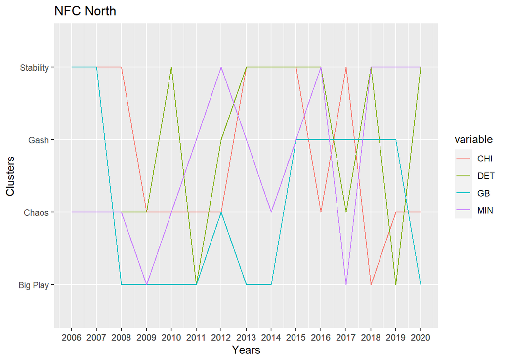

```r
gdxnn
```

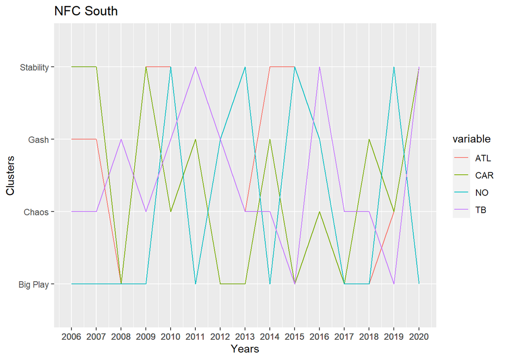

```r
gdxns
```

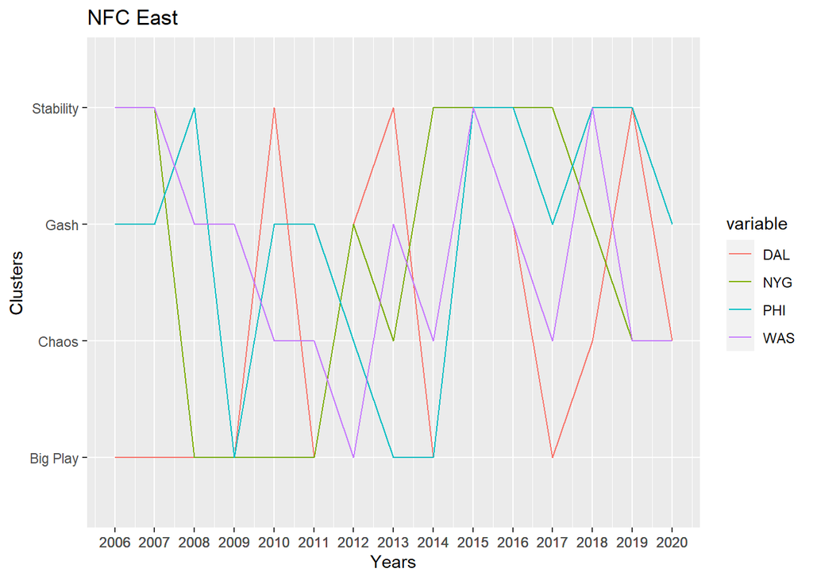

```r
gdxne
```

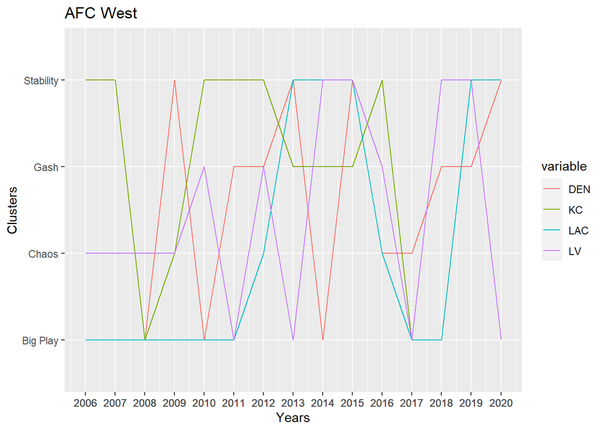

```r
gdxaw
```

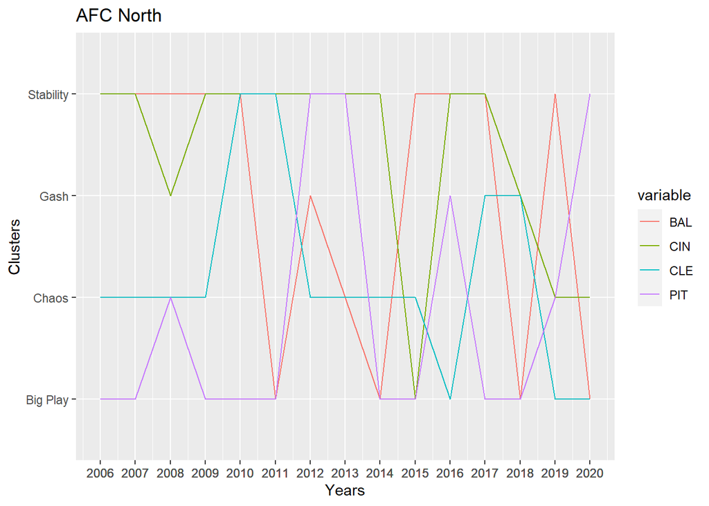

```r
gdxan
```

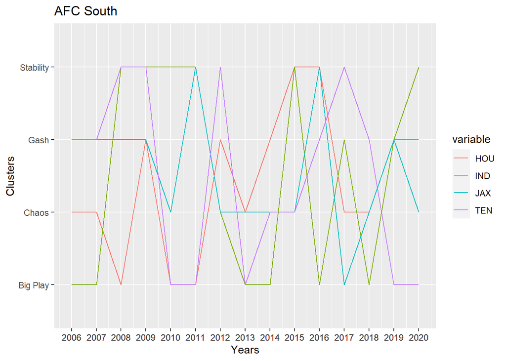

```r
gdxas
```

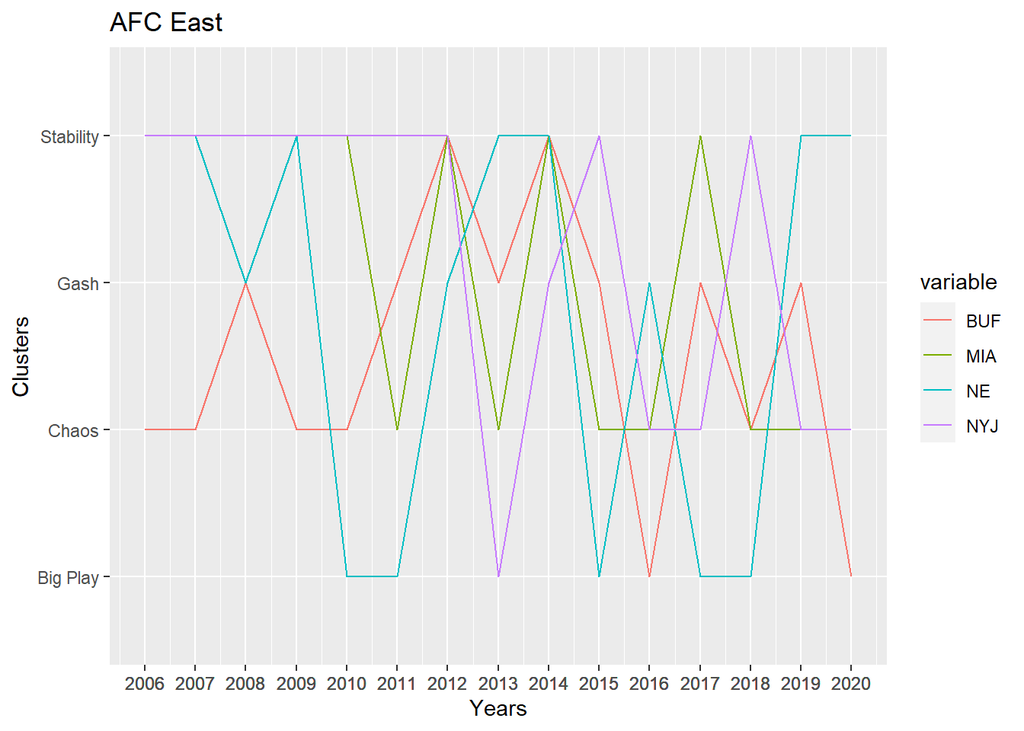

```r
gdxae
```

#Using clusters for each team, this summarises the average epa for each type against each defensive type. It is also split up by first and second down as well as play type and location.

```r
pbp$offensivetype <- NA
for(i in 1:nrow(fx)){
  pbp$offensivetype[which(pbp$season == fx$year[i] & pbp$posteam == fx$variable[i])] = fx$value[i]

}

pbp$defensivetype <- NA
for(i in 1:nrow(dx)){
  pbp$defensivetype[which(pbp$season == dx$year[i] & pbp$posteam == dx$variable[i])] = dx$value[i]

}
```

```r
epaavgs <- pbp %>%
  filter(play_type != 'no_play' & down == 1 | down == 2 ) %>%
  select(offensivetype, defensivetype, down, play_type, pass_location, pass_length, run_location, run_gap, epa) %>%
  group_by(offensivetype, defensivetype, down, play_type, pass_location, pass_length, run_location, run_gap) %>%
  summarise(epa = mean(epa)) %>%
  arrange(desc(epa))
epaavgs
```

```
## # A tibble: 597 x 9
## # Groups:   offensivetype, defensivetype, down, play_type, pass_location,
## #   pass_length, run_location [389]
##    offensivetype  defensivetype  down play_type pass_location pass_length
##    <chr>          <chr>         <dbl> <chr>     <chr>         <chr>
##  1 <NA>           <NA>              1 run       <NA>          <NA>
##  2 Ground & Pound Stability         2 run       <NA>          <NA>
##  3 <NA>           <NA>              2 pass      left          deep
##  4 Shots          Big Play          2 run       <NA>          <NA>
##  5 <NA>           <NA>              1 pass      left          deep
##  6 Damage Control Big Play          2 pass      right         deep
##  7 Damage Control Big Play          1 pass      middle        deep
##  8 <NA>           <NA>              1 pass      middle        deep
##  9 Ground & Pound Big Play          2 pass      middle        deep
## 10 Balance        Chaos             1 pass      right         deep
## # ... with 587 more rows, and 3 more variables: run_location <chr>,
## #   run_gap <chr>, epa <dbl>
```

#This function will take the offensive type: ‘Balance’, ‘Ground & Pound’, ‘Shots’, or ‘Damage Control’ and defensive type: ‘Stability’, ‘Gash’, ‘Big Play’, or ‘Chaos’ and lastly the down.

```r
bestplay <- function(offense, defense, down){

  offdef <- subset(epaavgs, epaavgs$offensivetype == offense & epaavgs$defensivetype == defense & epaavgs$down == down & play_type != 'no_play')

  offdef <- offdef %>%
    group_by(play_type, pass_location, pass_length, run_gap) %>%
    summarise(epa = max(epa)) %>%
    arrange(desc(epa))


  return(offdef)

}
```

#It will return the most ideal play to run for the inputed situation. If there are extenuating circumstances (game specific things, player issues, etc), alternative plays are still given.

```r
bestplay('Shots', 'Stability', 1)
```

```
## # A tibble: 12 x 5
## # Groups:   play_type, pass_location, pass_length [8]
##    play_type pass_location pass_length run_gap     epa
##    <chr>     <chr>         <chr>       <chr>     <dbl>
##  1 pass      middle        deep        <NA>     0.407
##  2 pass      left          deep        <NA>     0.246
##  3 pass      right         deep        <NA>     0.239
##  4 pass      middle        short       <NA>     0.151
##  5 pass      right         short       <NA>     0.103
##  6 run       <NA>          <NA>        <NA>     0.0816
##  7 pass      left          short       <NA>     0.0785
##  8 run       <NA>          <NA>        end      0.0625
##  9 run       <NA>          <NA>        guard    0.0295
## 10 run       <NA>          <NA>        tackle  -0.0370
## 11 run       <NA>          <NA>        center  -0.124
## 12 pass      <NA>          <NA>        <NA>    -1.46
```

###Success Predictions

#This creates a successful down on self-set metrics. A positive play on first down is a third of the distance to go (4 yards on 1st and 10) and on second down is half of the distance to go (4 yards on 2nd and 8).

```r
pbp$succdown <- as.numeric((pbp$play_type != 'no_play') & ( (pbp$down == 1 & (pbp$yards_gained >= (pbp$ydstogo / 3))) | (pbp$down == 2 & (pbp$yards_gained >= (pbp$ydstogo / 2)))))
```

#These are the variables that will be used for prediction metrics. It includes basic play information as well as the clustering data that was used as well as weather metrics.

```r
xgpbp <- pbp %>%
  filter( (down == 1 | down == 2) & (play_type == 'pass' | play_type == 'run') ) %>%
  select(season, posteam, down, play_type, yards_gained, ydstogo, succdown, pass_oe, OSrun, ISrun, air_yards, yards_after_catch, qb_scramble, qb_hit, sack, first_down_pass, yps, interception, fumble_lost, penalty_yards, highwind, cold, hot, rain, snow, explosive, series_success)
```

#Creating x variables and seperating data before 2020 as training and 2020 as test

```r
xgpbp[is.na(xgpbp)] <- 0
x_vars <- model.matrix(series_success ~ .,
                       data = xgpbp[, c(2:27)])[,-1]
dim(x_vars)
```

```
## [1] 537958     55
```

```r
x_vars_train <- x_vars[xgpbp$season < 2020,]
x_vars_test <- x_vars[xgpbp$season >= 2020,]

success_train <- xgpbp$series_success[xgpbp$season < 2020]
success_test <- xgpbp$series_success[xgpbp$season >= 2020]
```

```r
dx <- xgb.DMatrix(data = as.matrix(x_vars_train), label =  success_train)
dx_test <- xgb.DMatrix(data = as.matrix(x_vars_test), label =  success_test)
```

#Baseline XGBoost model

```r
set.seed(111111)
bst_1 <- xgboost(data = dx,

               nrounds = 100,

               verbose = 1,
                print_every_n = 20,

               objective = "binary:logistic",
               eval_metric = "auc",
               eval_metric = "error")
```

#Analyzing success based on initial modelling

```r
xgpreds <- predict(bst_1, x_vars_test)

xpreds_class <- rep(0, length(xgpreds))
xpreds_class[xgpreds >= 0.5] <-1

t <- table(xpreds_class, success_test)
confusionMatrix(t, positive = "1")
```

```
## Confusion Matrix and Statistics
##
##             success_test
## xpreds_class     0     1
##            0  3563  2205
##            1  3761 15767
##
##                Accuracy : 0.7642
##                  95% CI : (0.7589, 0.7694)
##     No Information Rate : 0.7105
##     P-Value [Acc > NIR] : < 2.2e-16
##
##                   Kappa : 0.3882
##
##  Mcnemar's Test P-Value : < 2.2e-16
##
##             Sensitivity : 0.8773
##             Specificity : 0.4865
##          Pos Pred Value : 0.8074
##          Neg Pred Value : 0.6177
##              Prevalence : 0.7105
##          Detection Rate : 0.6233
##    Detection Prevalence : 0.7720
##       Balanced Accuracy : 0.6819
##
##        'Positive' Class : 1
##
```

#Tuning ETA parameter to optimize results

```r
bst_mod_1 <- xgb.cv(data = x_vars,
                    label = xgpbp$series_success,
                    nfold = 5,
                    eta = 0.3,
                    max.depth = 7,
                    min_child_weight = 10,
                    gamma = 0,
                    subsample = 0.9,
                    colsample_bytree =  0.9,
                    nrounds = 1000,
                    early_stopping_rounds = 20,
                    verbose = 1,
                    nthread = 1,
                    print_every_n = 20,
                    objective = "binary:logistic",
                    eval_metric = "auc",
                    eval_metric = "error")
```

```
## Multiple eval metrics are present. Will use test_error for early stopping.
## Will train until test_error hasn't improved in 20 rounds.
##
## Stopping. Best iteration:
```

```r
bst_mod_2 <- xgb.cv(data = x_vars,
                    label = xgpbp$series_success,
                    nfold = 5,
                    eta = 0.1,
                    max.depth = 7,
                    min_child_weight = 10,
                    gamma = 0,
                    subsample = 0.9,
                    colsample_bytree =  0.9,
                    nrounds = 1000,
                    early_stopping_rounds = 20,
                    verbose = 1,
                    nthread = 1,
                    print_every_n = 20,
                    objective = "binary:logistic",
                    eval_metric = "auc",
                    eval_metric = "error")
```

```
## Multiple eval metrics are present. Will use test_error for early stopping.
## Will train until test_error hasn't improved in 20 rounds.
##
## Stopping. Best iteration:
```

```r
bst_mod_3 <- xgb.cv(data = x_vars,
                    label = xgpbp$series_success,
                    nfold = 5,
                    eta = 0.05,
                    max.depth = 7,
                    min_child_weight = 10,
                    gamma = 0,
                    subsample = 0.9,
                    colsample_bytree =  0.9,
                    nrounds = 1000,
                    early_stopping_rounds = 20,
                    verbose = 1,
                    nthread = 1,
                    print_every_n = 20,
                    objective = "binary:logistic",
                    eval_metric = "auc",
                    eval_metric = "error")
```

```
## Multiple eval metrics are present. Will use test_error for early stopping.
## Will train until test_error hasn't improved in 20 rounds.
##
## Stopping. Best iteration:
```

```r
bst_mod_4 <- xgb.cv(data = x_vars,
                    label = xgpbp$series_success,
                    nfold = 5,
                    eta = 0.01,
                    max.depth = 7,
                    min_child_weight = 10,
                    gamma = 0,
                    subsample = 0.9,
                    colsample_bytree =  0.9,
                    nrounds = 1000,
                    early_stopping_rounds = 20,
                    verbose = 1,
                    nthread = 1,
                    print_every_n = 20,
                    objective = "binary:logistic",
                    eval_metric = "auc",
                    eval_metric = "error")
```

```
## Multiple eval metrics are present. Will use test_error for early stopping.
## Will train until test_error hasn't improved in 20 rounds.
##
## Stopping. Best iteration:
```

```r
bst_mod_5 <- xgb.cv(data = x_vars,
                    label = xgpbp$series_success,
                    nfold = 5,
                    eta = 0.005,
                    max.depth = 7,
                    min_child_weight = 10,
                    gamma = 0,
                    subsample = 0.9,
                    colsample_bytree =  0.9,
                    nrounds = 1000,
                    early_stopping_rounds = 20,
                    verbose = 1,
                    nthread = 1,
                    print_every_n = 20,
                    objective = "binary:logistic",
                    eval_metric = "auc",
                    eval_metric = "error")
```

```
## Multiple eval metrics are present. Will use test_error for early stopping.
## Will train until test_error hasn't improved in 20 rounds.
##
## Stopping. Best iteration:
```

```r
bstfinal <- xgboost(data = x_vars_train,
                    label = success_train,
                    nfold = 5,

                    eta = .05,

                    max.depth = 7,
                    min_child_weight = 10,
                    gamma = 0,
                    subsample = 0.9,
                    colsample_bytree =  0.9,
                    nrounds = 1000,
                    early_stopping_rounds = 20,
                    verbose = 1,
                    nthread = 1,
                    print_every_n = 20,
                    objective = "binary:logistic",
                    eval_metric = "auc",
                    eval_metric = "error")
```

```
## [19:49:38] WARNING: amalgamation/../src/learner.cc:573:
## Parameters: { "nfold" } might not be used.
##
##   This may not be accurate due to some parameters are only used in language bindings but
##   passed down to XGBoost core.  Or some parameters are not used but slip through this
##   verification. Please open an issue if you find above cases.
##
##
## Multiple eval metrics are present. Will use train_error for early stopping.
## Will train until train_error hasn't improved in 20 rounds.
##
## Stopping. Best iteration:
```

#Applying optimized ETA to series success.

```r
tunedetaboost <- xgboost(data = x_vars,
                    label = xgpbp$series_success,
                    nfold = 5,

                    eta = .05,

                    max.depth = 7,
                    min_child_weight = 10,
                    gamma = 0,
                    subsample = 0.9,
                    colsample_bytree =  0.9,
                    nrounds = 1000,
                    early_stopping_rounds = 20,
                    verbose = 1,
                    nthread = 1,
                    print_every_n = 20,
                    objective = "binary:logistic",
                    eval_metric = "auc",
                    eval_metric = "error")
```

```
## [19:50:28] WARNING: amalgamation/../src/learner.cc:573:
## Parameters: { "nfold" } might not be used.
##
##   This may not be accurate due to some parameters are only used in language bindings but
##   passed down to XGBoost core.  Or some parameters are not used but slip through this
##   verification. Please open an issue if you find above cases.
##
##
## Multiple eval metrics are present. Will use train_error for early stopping.
## Will train until train_error hasn't improved in 20 rounds.
##
```

#Seeing official values

```r
seriessuccpreds <- predict(bstfinal, x_vars_test)


sspreds_class <- rep(0, length(seriessuccpreds))
sspreds_class[seriessuccpreds >= 0.5] <-1

t1 <- table(sspreds_class, success_test)
confusionMatrix(t1, positive = "1")
```

```
## Confusion Matrix and Statistics
##
##              success_test
## sspreds_class     0     1
##             0  3385  2039
##             1  3939 15933
##
##                Accuracy : 0.7637
##                  95% CI : (0.7584, 0.7689)
##     No Information Rate : 0.7105
##     P-Value [Acc > NIR] : < 2.2e-16
##
##                   Kappa : 0.3778
##
##  Mcnemar's Test P-Value : < 2.2e-16
##
##             Sensitivity : 0.8865
##             Specificity : 0.4622
##          Pos Pred Value : 0.8018
##          Neg Pred Value : 0.6241
##              Prevalence : 0.7105
##          Detection Rate : 0.6299
##    Detection Prevalence : 0.7856
##       Balanced Accuracy : 0.6744
##
##        'Positive' Class : 1
##
```

#Add predicted values to dataframe so it can be used in full game success predictions

```r
predsxx <- predict(tunedetaboost, x_vars)
xgpbp$predictedseriessuccess <- round(predsxx, 4)
```

#Create a column for winners that will be used as what is to be predicted

```r
results <- pbp %>%
  filter((down == 1 | down == 2) & (play_type == 'pass' | play_type == 'run')) %>%
  group_by(game_id) %>%
  select(home_team, away_team, home_score, away_score)
results$winner <- ifelse(results$home_score > results$away_score, results$home_team,
ifelse(results$home_score == results$away_score, NA, results$away_team))



xgpbp$winner <- results$winner

xgpbp$winner <- as.numeric(xgpbp$posteam == xgpbp$winner)

xgpbp
```

```
## # A tibble: 537,958 x 29
##    season posteam  down play_type yards_gained ydstogo succdown pass_oe OSrun
##     <int> <chr>   <dbl> <chr>            <dbl>   <dbl>    <dbl>   <dbl> <dbl>
##  1   1999 PHI         1 pass                 0      10        0       0     0
##  2   1999 PHI         2 run                  1      10        0       0     0
##  3   1999 ARI         1 run                  1      10        0       0     1
##  4   1999 ARI         2 run                  4       9        0       0     0
##  5   1999 PHI         1 run                  7      10        1       0     1
##  6   1999 PHI         2 pass                15       3        1       0     0
##  7   1999 PHI         1 run                  1      10        0       0     0
##  8   1999 PHI         2 pass                 6       9        1       0     0
##  9   1999 PHI         1 run                  3      10        0       0     1
## 10   1999 PHI         2 run                 24       7        1       0     0
## # ... with 537,948 more rows, and 20 more variables: ISrun <dbl>,
## #   air_yards <dbl>, yards_after_catch <dbl>, qb_scramble <dbl>, qb_hit <dbl>,
## #   sack <dbl>, first_down_pass <dbl>, yps <dbl>, interception <dbl>,
## #   fumble_lost <dbl>, penalty_yards <dbl>, highwind <dbl>, cold <dbl>,
## #   hot <dbl>, rain <dbl>, snow <dbl>, explosive <dbl>, series_success <dbl>,
## #   predictedseriessuccess <dbl>, winner <dbl>
```

```r
losers <- subset(xgpbp, is.na(xgpbp$winner))
dim(losers)
```

```
## [1] 1322   29
```

```r
xgpbp <- anti_join(xgpbp, losers)
dim(xgpbp)
```

```
## [1] 536636     29
```

```r
summary(xgpbp)
```

```
##      season       posteam               down        play_type
##  Min.   :1999   Length:536636      Min.   :1.000   Length:536636
##  1st Qu.:2004   Class :character   1st Qu.:1.000   Class :character
##  Median :2010   Mode  :character   Median :1.000   Mode  :character
##  Mean   :2010                      Mean   :1.431
##  3rd Qu.:2015                      3rd Qu.:2.000
##  Max.   :2020                      Max.   :2.000
##   yards_gained        ydstogo          succdown         pass_oe
##  Min.   :-29.000   Min.   : 1.000   Min.   :0.0000   Min.   :-99.24
##  1st Qu.:  0.000   1st Qu.: 8.000   1st Qu.:0.0000   1st Qu.:-33.60
##  Median :  3.000   Median :10.000   Median :0.0000   Median :  0.00
##  Mean   :  5.421   Mean   : 9.091   Mean   :0.4966   Mean   : -0.41
##  3rd Qu.:  8.000   3rd Qu.:10.000   3rd Qu.:1.0000   3rd Qu.: 27.35
##  Max.   : 99.000   Max.   :48.000   Max.   :1.0000   Max.   : 97.72
##      OSrun            ISrun         air_yards       yards_after_catch
##  Min.   :0.0000   Min.   :0.000   Min.   :-93.000   Min.   :-40.000
##  1st Qu.:0.0000   1st Qu.:0.000   1st Qu.:  0.000   1st Qu.:  0.000
##  Median :0.0000   Median :0.000   Median :  0.000   Median :  0.000
##  Mean   :0.2402   Mean   :0.232   Mean   :  2.806   Mean   :  1.145
##  3rd Qu.:0.0000   3rd Qu.:0.000   3rd Qu.:  2.000   3rd Qu.:  0.000
##  Max.   :1.0000   Max.   :1.000   Max.   : 69.000   Max.   : 91.000
##   qb_scramble          qb_hit            sack         first_down_pass
##  Min.   :0.00000   Min.   :0.0000   Min.   :0.00000   Min.   :0.0000
##  1st Qu.:0.00000   1st Qu.:0.0000   1st Qu.:0.00000   1st Qu.:0.0000
##  Median :0.00000   Median :0.0000   Median :0.00000   Median :0.0000
##  Mean   :0.01565   Mean   :0.0488   Mean   :0.02827   Mean   :0.1572
##  3rd Qu.:0.00000   3rd Qu.:0.0000   3rd Qu.:0.00000   3rd Qu.:0.0000
##  Max.   :1.00000   Max.   :1.0000   Max.   :1.00000   Max.   :1.0000
##       yps             interception      fumble_lost       penalty_yards
##  Min.   :-100.0000   Min.   :0.00000   Min.   :0.000000   Min.   : 0.0000
##  1st Qu.:   0.0000   1st Qu.:0.00000   1st Qu.:0.000000   1st Qu.: 0.0000
##  Median :   0.0000   Median :0.00000   Median :0.000000   Median : 0.0000
##  Mean   :  -0.4467   Mean   :0.01277   Mean   :0.007532   Mean   : 0.1591
##  3rd Qu.:   0.0000   3rd Qu.:0.00000   3rd Qu.:0.000000   3rd Qu.: 0.0000
##  Max.   :  59.0000   Max.   :1.00000   Max.   :1.000000   Max.   :30.0000
##     highwind           cold              hot                rain
##  Min.   :0.0000   Min.   :0.00000   Min.   :0.000000   Min.   :0.000000
##  1st Qu.:0.0000   1st Qu.:0.00000   1st Qu.:0.000000   1st Qu.:0.000000
##  Median :0.0000   Median :0.00000   Median :0.000000   Median :0.000000
##  Mean   :0.0987   Mean   :0.01812   Mean   :0.008167   Mean   :0.007461
##  3rd Qu.:0.0000   3rd Qu.:0.00000   3rd Qu.:0.000000   3rd Qu.:0.000000
##  Max.   :1.0000   Max.   :1.00000   Max.   :1.000000   Max.   :1.000000
##       snow            explosive       series_success   predictedseriessuccess
##  Min.   :0.000000   Min.   :0.00000   Min.   :0.0000   Min.   :0.0001
##  1st Qu.:0.000000   1st Qu.:0.00000   1st Qu.:0.0000   1st Qu.:0.4833
##  Median :0.000000   Median :0.00000   Median :1.0000   Median :0.6201
##  Mean   :0.002119   Mean   :0.03235   Mean   :0.6521   Mean   :0.6521
##  3rd Qu.:0.000000   3rd Qu.:0.00000   3rd Qu.:1.0000   3rd Qu.:0.9320
##  Max.   :1.000000   Max.   :1.00000   Max.   :1.0000   Max.   :1.0000
##      winner
##  Min.   :0.0000
##  1st Qu.:0.0000
##  Median :1.0000
##  Mean   :0.5099
##  3rd Qu.:1.0000
##  Max.   :1.0000
```

#Same steps for full game adding columns for predicted series success and winner made above

```r
x_vars2 <- model.matrix(winner ~.,
                       data = xgpbp[,c(2:29)])[,-1]
dim(x_vars2)
```

```
## [1] 536636     57
```

```r
x_vars2_train <- x_vars2[xgpbp$season < 2020,]
x_vars2_test <- x_vars2[xgpbp$season >= 2020,]

success2_train <- xgpbp$winner[xgpbp$season < 2020]
success2_test <- xgpbp$winner[xgpbp$season >= 2020]


dy <- xgb.DMatrix(data = as.matrix(x_vars2_train), label =  success2_train)
dy_test <- xgb.DMatrix(data = as.matrix(x_vars2_test), label =  success2_test)
```

```r
set.seed(111111)
bst_2 <- xgboost(data = dy,

               nrounds = 100,

               verbose = 1,
                print_every_n = 20,

               objective = "binary:logistic",
               eval_metric = "auc",
               eval_metric = "error")
xgwinpreds <- predict(bst_2, x_vars2_test)

xwinpreds_class <- rep(0, length(xgwinpreds))
xwinpreds_class[xgwinpreds >= 0.5] <-1

t2 <- table(xwinpreds_class, success2_test)
confusionMatrix(t2, positive = "1")
```

```
## Confusion Matrix and Statistics
##
##                success2_test
## xwinpreds_class    0    1
##               0 7973 4769
##               1 4462 7973
##
##                Accuracy : 0.6334
##                  95% CI : (0.6274, 0.6393)
##     No Information Rate : 0.5061
##     P-Value [Acc > NIR] : < 2.2e-16
##
##                   Kappa : 0.2668
##
##  Mcnemar's Test P-Value : 0.001448
##
##             Sensitivity : 0.6257
##             Specificity : 0.6412
##          Pos Pred Value : 0.6412
##          Neg Pred Value : 0.6257
##              Prevalence : 0.5061
##          Detection Rate : 0.3167
##    Detection Prevalence : 0.4939
##       Balanced Accuracy : 0.6335
##
##        'Positive' Class : 1
##
```

```r
bst_mod_6 <- xgb.cv(data = x_vars2,
                    label = xgpbp$winner,
                    nfold = 5,
                    eta = 0.3,
                    max.depth = 7,
                    min_child_weight = 10,
                    gamma = 0,
                    subsample = 0.9,
                    colsample_bytree =  0.9,
                    nrounds = 1000,
                    early_stopping_rounds = 20,
                    verbose = 1,
                    nthread = 1,
                    print_every_n = 20,
                    objective = "binary:logistic",
                    eval_metric = "auc",
                    eval_metric = "error")
```

```
## Multiple eval metrics are present. Will use test_error for early stopping.
## Will train until test_error hasn't improved in 20 rounds.
##
## Stopping. Best iteration:
```

```r
bst_mod_7 <- xgb.cv(data = x_vars2,
                    label = xgpbp$winner,
                    nfold = 5,
                    eta = 0.1,
                    max.depth = 7,
                    min_child_weight = 10,
                    gamma = 0,
                    subsample = 0.9,
                    colsample_bytree =  0.9,
                    nrounds = 1000,
                    early_stopping_rounds = 20,
                    verbose = 1,
                    nthread = 1,
                    print_every_n = 20,
                    objective = "binary:logistic",
                    eval_metric = "auc",
                    eval_metric = "error")
```

```
## Multiple eval metrics are present. Will use test_error for early stopping.
## Will train until test_error hasn't improved in 20 rounds.
##
## Stopping. Best iteration:
```

```r
bst_mod_8 <- xgb.cv(data = x_vars2,
                    label = xgpbp$winner,
                    nfold = 5,
                    eta = 0.05,
                    max.depth = 7,
                    min_child_weight = 10,
                    gamma = 0,
                    subsample = 0.9,
                    colsample_bytree =  0.9,
                    nrounds = 1000,
                    early_stopping_rounds = 20,
                    verbose = 1,
                    nthread = 1,
                    print_every_n = 20,
                    objective = "binary:logistic",
                    eval_metric = "auc",
                    eval_metric = "error")
```

```
## Multiple eval metrics are present. Will use test_error for early stopping.
## Will train until test_error hasn't improved in 20 rounds.
##
## Stopping. Best iteration:
```

```r
bst_mod_9 <- xgb.cv(data = x_vars2,
                    label = xgpbp$winner,
                    nfold = 5,
                    eta = 0.01,
                    max.depth = 7,
                    min_child_weight = 10,
                    gamma = 0,
                    subsample = 0.9,
                    colsample_bytree =  0.9,
                    nrounds = 1000,
                    early_stopping_rounds = 20,
                    verbose = 1,
                    nthread = 1,
                    print_every_n = 20,
                    objective = "binary:logistic",
                    eval_metric = "auc",
                    eval_metric = "error")
```

```
## Multiple eval metrics are present. Will use test_error for early stopping.
## Will train until test_error hasn't improved in 20 rounds.
##
```

```r
bst_mod_10 <- xgb.cv(data = x_vars2,
                    label = xgpbp$winner,
                    nfold = 5,
                    eta = 0.005,
                    max.depth = 7,
                    min_child_weight = 10,
                    gamma = 0,
                    subsample = 0.9,
                    colsample_bytree =  0.9,
                    nrounds = 1000,
                    early_stopping_rounds = 20,
                    verbose = 1,
                    nthread = 1,
                    print_every_n = 20,
                    objective = "binary:logistic",
                    eval_metric = "auc",
                    eval_metric = "error")
```

```
## Multiple eval metrics are present. Will use test_error for early stopping.
## Will train until test_error hasn't improved in 20 rounds.
##
```

```r
bstfinal2 <- xgboost(data = x_vars2_train,
                    label = success2_train,
                    nfold = 5,
                    eta = .05,
                    max.depth = 7,
                    min_child_weight = 10,
                    gamma = 0,
                    subsample = 0.9,
                    colsample_bytree =  0.9,
                    nrounds = 1000,
                    early_stopping_rounds = 20,
                    verbose = 1,
                    nthread = 1,
                    print_every_n = 20,
                    objective = "binary:logistic",
                    eval_metric = "auc",
                    eval_metric = "error")
```

```
## [01:06:27] WARNING: amalgamation/../src/learner.cc:573:
## Parameters: { "nfold" } might not be used.
##
##   This may not be accurate due to some parameters are only used in language bindings but
##   passed down to XGBoost core.  Or some parameters are not used but slip through this
##   verification. Please open an issue if you find above cases.
##
##
## Multiple eval metrics are present. Will use train_error for early stopping.
## Will train until train_error hasn't improved in 20 rounds.
##
```

```r
gameresultpreds <- predict(bstfinal2, x_vars2_test)


grpreds_class <- rep(0, length(gameresultpreds))
grpreds_class[gameresultpreds >= 0.5] <-1

t3 <- table(grpreds_class, success2_test)
confusionMatrix(t3, positive = "1")
```

```
## Confusion Matrix and Statistics
##
##              success2_test
## grpreds_class    0    1
##             0 7957 4805
##             1 4478 7937
##
##                Accuracy : 0.6313
##                  95% CI : (0.6253, 0.6373)
##     No Information Rate : 0.5061
##     P-Value [Acc > NIR] : < 2.2e-16
##
##                   Kappa : 0.2627
##
##  Mcnemar's Test P-Value : 0.0007155
##
##             Sensitivity : 0.6229
##             Specificity : 0.6399
##          Pos Pred Value : 0.6393
##          Neg Pred Value : 0.6235
##              Prevalence : 0.5061
##          Detection Rate : 0.3152
##    Detection Prevalence : 0.4931
##       Balanced Accuracy : 0.6314
##
##        'Positive' Class : 1
##
```

#Visualization of the importance of each variable

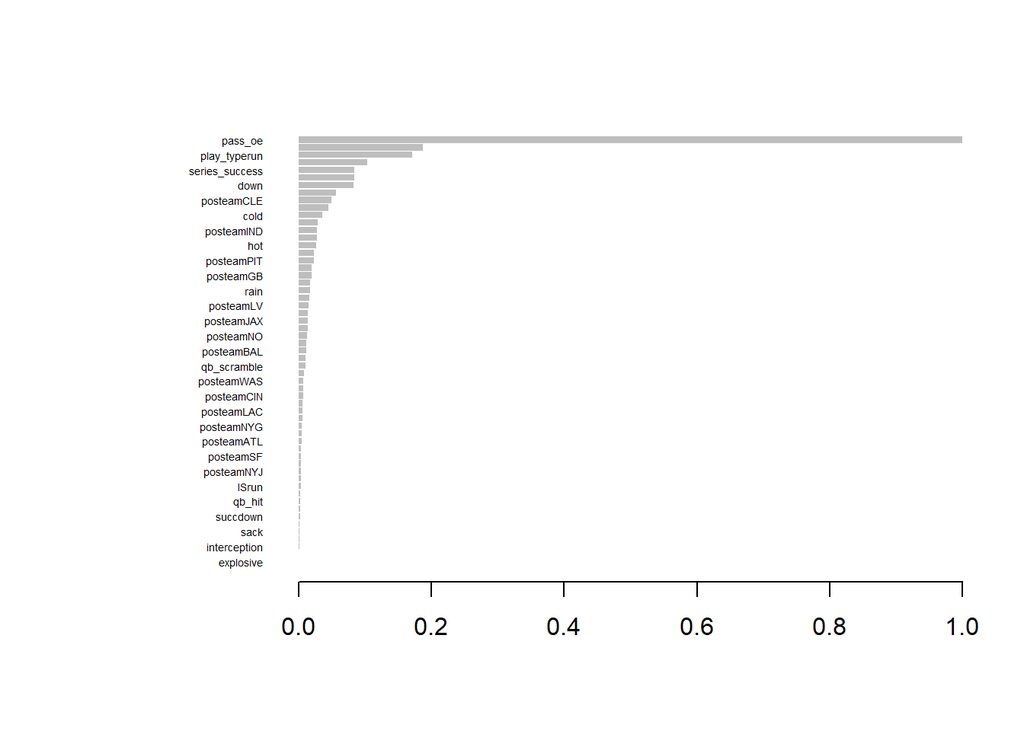

```r
importance_matrix <- xgb.importance(colnames(dy), model = bstfinal2)

#importance_matrix <- importance_matrix[0:10, c(1,5)]

xgb.plot.importance(importance_matrix, rel_to_first = TRUE)
```